# CKME 136 Capstone

TODD BETHELL

July 19, 2019

#### !!NOTE!! This will install ALL of the caret package - which will take several minutes - so comment the install out if you do not want to install the full caret package.

install.packages(“caret”, dependencies = c(“Depends”, “Suggests”)) install.packages(“PerformanceAnalytics”) install.packages(“lsr”) install.packages(“tidyverse”) install.packages(“dplyr”) install.packages(“class”) install.packages(“gmodels”) install.packages(“corrplot”) install.packages(“RCurl”) install.packages(“GGally”) install.packages(“FSelector”) install.packages(“FSelectorRcpp”) install.packages(“mlbench”) install.packages(“caretEnsemble”) install.packages(“skimr”) install.packages(“tictoc”) install.packages(“effsize”) install.packages(“pscl”) install.packages(“klaR”) install.packages(“DMwR”) install.packages(“caTools”) library(GGally) library(knitr) library(RCurl) library(caret) library(PerformanceAnalytics) library(lsr) library(tidyverse) library(dplyr) library(class) library(gmodels) library(corrplot) library(GGally) library(FSelectorRcpp) library(caretEnsemble) library(skimr) library(tictoc) library(effsize) library(pscl) library(klaR) library(DMwR) library(caTools) —

```r
library(knitr)
library(RCurl)
library(caret)
library(PerformanceAnalytics)
library(lsr)
library(tidyverse)
library(dplyr)
library(plyr)
library(class)
library(gmodels)
library(corrplot)
library(GGally)
library(FSelectorRcpp)
library(caretEnsemble)
library(skimr)
library(tictoc)
library(effsize)
library(pscl)
library(klaR)
library(DMwR)
library(caTools)
```

```r
FullSetB4<-read.csv(file="https://raw.githubusercontent.com/ToddB11/TB136capstone/master/ZAlizadeh_dataset.csv",header=T,sep=",")
```

#### Review Data Set

```r
head(FullSetB4)
```

```
##   ï..Age Weight Length   Sex      BMI DM HTN Smoker ExSmoker FH Obesity
## 1     53     90    175  Male 29.38776  0   1      1        0  0       Y
## 2     67     70    157 Fmale 28.39872  0   1      0        0  0       Y
## 3     54     54    164  Male 20.07733  0   0      1        0  0       N
## 4     66     67    158 Fmale 26.83865  0   1      0        0  0       Y
## 5     50     87    153 Fmale 37.16519  0   1      0        0  0       Y
## 6     50     75    175  Male 24.48980  0   0      1        0  0       N
##   CRF CVA AD TD CHF DLP  BP  PR Edema WPP LR SysM DiaM TCP Dyspnea Fclass
## 1   N   N  N  N   N   Y 110  80     0   N  N    N    N   0       N      0
## 2   N   N  N  N   N   N 140  80     1   N  N    N    N   1       N      0
## 3   N   N  N  N   N   N 100 100     0   N  N    N    N   1       N      0
## 4   N   N  N  N   N   N 100  80     0   N  N    N    Y   0       Y      3
## 5   N   N  N  N   N   N 110  80     0   N  N    Y    N   0       Y      2
## 6   N   N  N  N   N   N 118  70     0   N  N    N    N   1       N      3
##   ACP NCP ECP LTAng QWave STelev STdep Tinv LVH PoorR BBB FBS  Cr  TG LDL
## 1   N   N   N     N     0      0     1    1   N     N   N  90 0.7 250 155
## 2   N   N   N     N     0      0     1    1   N     N   N  80 1.0 309 121
## 3   N   N   N     N     0      0     0    0   N     N   N  85 1.0 103  70
## 4   N   Y   N     N     0      0     1    0   N     N   N  78 1.2  63  55
## 5   N   N   N     N     0      0     0    0   N     N   N 104 1.0 170 110
## 6   N   N   N     N     0      0     0    0   N     N   N  86 1.0 139 119
##   HDL BUN ESR   Hb   K  Na   WBC Lymph Neut PLT EF RWMA    VHD    CAD
## 1  30   8   7 15.6 4.7 141  5700    39   52 261 50    0      N    Cad
## 2  36  30  26 13.9 4.7 156  7700    38   55 165 40    4      N    Cad
## 3  45  17  10 13.5 4.7 139  7400    38   60 230 40    2   mild    Cad
## 4  27  30  76 12.1 4.4 142 13000    18   72 742 55    0 Severe Normal
## 5  50  16  27 13.2 4.0 140  9200    55   39 274 50    0 Severe Normal
## 6  34  13  18 15.6 4.2 141  7300    26   66 194 50    0      N    Cad
```

```r
tail(FullSetB4)
```

```
##     ï..Age Weight Length   Sex      BMI DM HTN Smoker ExSmoker FH Obesity
## 298     30    100    172  Male 33.80206  0   0      1        0  1       Y
## 299     58     84    168  Male 29.76190  0   0      0        0  0       Y
## 300     55     64    152 Fmale 27.70083  0   0      0        0  0       Y
## 301     48     77    160 Fmale 30.07812  0   1      0        0  1       Y
## 302     57     90    159 Fmale 35.59986  1   0      0        0  0       Y
## 303     56     85    170 Fmale 29.41176  0   1      1        0  0       Y
##     CRF CVA AD TD CHF DLP  BP PR Edema WPP LR SysM DiaM TCP Dyspnea Fclass
## 298   N   N  N  N   N   N 110 60     0   N  N    N    N   0       N      0
## 299   N   N  N  N   N   N 100 76     0   N  N    N    N   1       N      0
## 300   N   N  N  N   N   N 100 60     0   N  N    Y    N   0       Y      0
## 301   N   N  N  N   N   N 130 70     0   N  N    N    N   0       N      0
## 302   N   N  N  N   N   N 100 60     0   N  N    N    N   0       Y      0
## 303   N   N  N  N   N   N 120 80     0   N  N    N    N   1       N      0
##     ACP NCP ECP LTAng QWave STelev STdep Tinv LVH PoorR  BBB FBS  Cr  TG
## 298   Y   N   N     N     0      0     0    0   N     N    N  83 1.0 205
## 299   N   N   N     N     0      0     0    0   N     N    N  92 1.0 112
## 300   Y   N   N     N     0      0     0    0   N     N LBBB  86 0.9 111
## 301   N   Y   N     N     0      0     0    0   N     N RBBB  83 1.0  93
## 302   Y   N   N     N     0      0     0    0   N     N    N  96 1.0 116
## 303   N   N   N     N     0      0     0    1   N     N    N  78 0.7 139
##     LDL HDL BUN ESR   Hb   K  Na   WBC Lymph Neut PLT EF RWMA  VHD    CAD
## 298  97  53  20  16 13.1 4.0 143  9100    39   60 294 55    1    N Normal
## 299 115  44  13  13 12.3 4.8 146  8500    34   58 251 45    0    N    Cad
## 300  40  23  23   3 12.4 4.0 139 11400    16   80 377 40    0 mild Normal
## 301 112  42  13  20 12.8 4.0 140  9000    35   55 279 55    0    N Normal
## 302 130  49  14  31 10.1 3.8 141  3800    48   40 208 55    0    N Normal
## 303 124  34  16  13 14.7 4.4 147  6000    32   55 302 55    0    N    Cad
```

```r
str(FullSetB4)
```

```
## 'data.frame':    303 obs. of  56 variables:
##  $ ï..Age  : int  53 67 54 66 50 50 55 72 58 60 ...
##  $ Weight  : int  90 70 54 67 87 75 80 80 84 71 ...
##  $ Length  : int  175 157 164 158 153 175 165 175 163 170 ...
##  $ Sex     : Factor w/ 2 levels "Fmale","Male": 2 1 2 1 1 2 2 2 1 2 ...
##  $ BMI     : num  29.4 28.4 20.1 26.8 37.2 ...
##  $ DM      : int  0 0 0 0 0 0 0 1 0 1 ...
##  $ HTN     : int  1 1 0 1 1 0 0 0 0 0 ...
##  $ Smoker  : int  1 0 1 0 0 1 0 1 0 0 ...
##  $ ExSmoker: int  0 0 0 0 0 0 1 0 0 0 ...
##  $ FH      : int  0 0 0 0 0 0 0 0 0 0 ...
##  $ Obesity : Factor w/ 2 levels "N","Y": 2 2 1 2 2 1 2 2 2 1 ...
##  $ CRF     : Factor w/ 2 levels "N","Y": 1 1 1 1 1 1 1 1 1 1 ...
##  $ CVA     : Factor w/ 2 levels "N","Y": 1 1 1 1 1 1 1 1 1 1 ...
##  $ AD      : Factor w/ 2 levels "N","Y": 1 1 1 1 1 1 1 1 1 1 ...
```

[output cut: 42 more lines]

#### Fixing ‘Age’ column header (not displaying correctly):

```r
names(FullSetB4)[1] <- "Age"
```

#### Remove ‘Length’ attribute - since not used in final study; and captured via BMI (and ‘Obesity’ uses ‘BMI’):

```r
FullSetB4 <- FullSetB4[-3]
dim(FullSetB4)
```

```
## [1] 303  55
```

### CHECKING FOR MISSING DATA & ERRORS:

#### Step one, review all integer and numeric variables statisitics (note: ‘inline histogram’ correction was needed to display correctly on rmarkdown):

```r
library(skimr)
library(knitr)
library(tidyverse)

skim1 <- FullSetB4[,c(1:2,16:17,36:50)]
skimr::skim(skim1) %>%
  filter(stat == "hist") %>%
  print.listof(locale = locale(encoding = "UTF-8"))
```

```
## variable :
##  [1] "Age"    "Weight" "BP"     "FBS"    "Cr"     "TG"     "LDL"
##  [8] "HDL"    "BUN"    "ESR"    "Hb"     "K"      "Na"     "WBC"
## [15] "Lymph"  "Neut"
##
## type :
##  [1] "integer" "integer" "integer" "integer" "numeric" "integer" "integer"
##  [8] "numeric" "integer" "integer" "numeric" "numeric" "integer" "integer"
## [15] "integer" "integer"
##
## stat :
##  [1] "hist" "hist" "hist" "hist" "hist" "hist" "hist" "hist" "hist" "hist"
## [11] "hist" "hist" "hist" "hist" "hist" "hist"
##
## level :
##  [1] ".all" ".all" ".all" ".all" ".all" ".all" ".all" ".all" ".all" ".all"
## [11] ".all" ".all" ".all" ".all" ".all" ".all"
##
## value :
##  [1] NA NA NA NA NA NA NA NA NA NA NA NA NA NA NA NA
##
## formatted :
##  [1] "▁▂▇▇▇▆▂▁" "▂▆▇▆▃▁▁▁" "▂▃▃▇▁▁▁▁" "▇▃▁▁▁▁▁▁" "▂▇▇▆▂▁▁▁" "▇▂▁▁▁▁▁▁"
##  [7] "▁▃▇▇▃▂▁▁" "▂▇▇▂▁▁▁▁" "▂▇▃▁▁▁▁▁" "▇▆▂▁▁▁▁▁" "▁▂▃▇▇▅▂▁" "▁▅▇▆▂▁▁▁"
## [13] "▁▁▃▇▃▁▁▁" "▃▇▆▃▂▁▁▁" "▁▂▃▇▇▃▁▁" "▁▂▆▇▆▃▂▁"
```

```r
skim2 <- skim_to_wide(skim1)
kable(skim2)
```

| type | variable | missing | complete | n | n_unique | top_counts | ordered | mean | sd | p0 | p25 | p50 | p75 | p100 | hist |
| --- | --- | --- | --- | --- | --- | --- | --- | --- | --- | --- | --- | --- | --- | --- | --- |
| factor | BBB | 0 | 303 | 303 | 3 | N: 282, LBB: 13, RBB: 8, NA: 0 | FALSE | NA | NA | NA | NA | NA | NA | NA | NA |
| factor | DLP | 0 | 303 | 303 | 2 | N: 191, Y: 112, NA: 0 | FALSE | NA | NA | NA | NA | NA | NA | NA | NA |
| factor | PoorR | 0 | 303 | 303 | 2 | N: 294, Y: 9, NA: 0 | FALSE | NA | NA | NA | NA | NA | NA | NA | NA |
| integer | Age | 0 | 303 | 303 | NA | NA | NA | 58.9 | 10.39 | 30 | 51 | 58 | 66 | 86 | ▁▂▇▇▇▆▂▁ |
| integer | BP | 0 | 303 | 303 | NA | NA | NA | 129.55 | 18.94 | 90 | 120 | 130 | 140 | 190 | ▂▃▃▇▁▁▁▁ |
| integer | BUN | 0 | 303 | 303 | NA | NA | NA | 17.5 | 6.96 | 6 | 13 | 16 | 20 | 52 | ▂▇▃▁▁▁▁▁ |
| integer | ESR | 0 | 303 | 303 | NA | NA | NA | 19.46 | 15.94 | 1 | 9 | 15 | 26 | 90 | ▇▆▂▁▁▁▁▁ |
| integer | FBS | 0 | 303 | 303 | NA | NA | NA | 119.18 | 52.08 | 62 | 88.5 | 98 | 130 | 400 | ▇▃▁▁▁▁▁▁ |
| integer | LDL | 0 | 303 | 303 | NA | NA | NA | 104.64 | 35.4 | 18 | 80 | 100 | 122 | 232 | ▁▃▇▇▃▂▁▁ |
| integer | Lymph | 0 | 303 | 303 | NA | NA | NA | 32.4 | 9.97 | 7 | 26 | 32 | 39 | 60 | ▁▂▃▇▇▃▁▁ |
| integer | Na | 0 | 303 | 303 | NA | NA | NA | 141 | 3.81 | 128 | 139 | 141 | 143 | 156 | ▁▁▃▇▃▁▁▁ |
| integer | Neut | 0 | 303 | 303 | NA | NA | NA | 60.15 | 10.18 | 32 | 52.5 | 60 | 67 | 89 | ▁▂▆▇▆▃▂▁ |
| integer | TG | 0 | 303 | 303 | NA | NA | NA | 150.34 | 97.96 | 37 | 90 | 122 | 177 | 1050 | ▇▂▁▁▁▁▁▁ |
| integer | WBC | 0 | 303 | 303 | NA | NA | NA | 7562.05 | 2413.74 | 3700 | 5800 | 7100 | 8800 | 18000 | ▃▇▆▃▂▁▁▁ |
| integer | Weight | 0 | 303 | 303 | NA | NA | NA | 73.83 | 11.99 | 48 | 65 | 74 | 81 | 120 | ▂▆▇▆▃▁▁▁ |
| numeric | Cr | 0 | 303 | 303 | NA | NA | NA | 1.06 | 0.26 | 0.5 | 0.9 | 1 | 1.2 | 2.2 | ▂▇▇▆▂▁▁▁ |
| numeric | Hb | 0 | 303 | 303 | NA | NA | NA | 13.15 | 1.61 | 8.9 | 12.2 | 13.2 | 14.2 | 17.6 | ▁▂▃▇▇▅▂▁ |
| numeric | HDL | 0 | 303 | 303 | NA | NA | NA | 40.23 | 10.56 | 15.9 | 33.5 | 39 | 45.5 | 111 | ▂▇▇▂▁▁▁▁ |
| numeric | K | 0 | 303 | 303 | NA | NA | NA | 4.23 | 0.46 | 3 | 3.9 | 4.2 | 4.5 | 6.6 | ▁▅▇▆▂▁▁▁ |

#### Check number of observations and whether there is any missing data:

```r
nrow(FullSetB4)
```

```
## [1] 303
```

```r
sum(is.na(FullSetB4))
```

```
## [1] 0
```

#### Double checking whether all observations are complete (no missing data): No incomplete cases found, but I am commenting this out for the html output - since the output is very long.

```r
# FullSetB4[complete.cases(FullSetB4),]
```

#### Checking for errors, starting with ‘Sex’ attribute (column 3):

```r
SexF <- sum(FullSetB4$Sex == 'Fmale')
SexM <- sum(FullSetB4$Sex == 'Male')
sum(SexF + SexM)
```

```
## [1] 303
```

#### Checking for errors in columns 5:9, 19, 24, 31:34 (must be ‘0’ or ‘1’)

```r
#library(tidyverse)
#library(dbplyr)

Bins0 <- FullSetB4%>%
  gather(x, value, 5:9,19,24,31:34)%>%
  tally(value == 0)
Bins1 <- FullSetB4%>%
  gather(x, value, 5:9,19,24,31:34)%>%
  tally(value == 1)
 (Bins0 + Bins1)/11
```

```
##     n
## 1 303
```

#### Checking for errors in columns 10:16, 20:23, 25, 27:28, 30, 35:36 (must be ‘Y’ or ‘N’)

```r
BinsY <- FullSetB4%>%
  gather(x, value, 10:16,20:23,25,27:28,30,35:36)%>%
  tally(value == 'Y')
BinsN <- FullSetB4%>%
  gather(x, value, 10:16,20:23,25,27:28,30,35:36)%>%
  tally(value == 'N')
 (BinsY + BinsN)/17
```

```
##     n
## 1 303
```

#### Checking for errors in the ‘BBB’(Bundle Branch Block) attribute (column 37):

```r
nBBB <- sum(FullSetB4$BBB == 'N')
LBBB <- sum(FullSetB4$BBB == 'LBBB')
RBBB <- sum(FullSetB4$BBB == 'RBBB')
sum(nBBB+LBBB+RBBB)
```

```
## [1] 303
```

#### Checking for errors in the ‘VHD’(Valvular Heart Disease) attribute (column 54):

```r
Vmild <- sum(FullSetB4$VHD == 'mild')
VMod <- sum(FullSetB4$VHD == 'Moderate')
VN <- sum(FullSetB4$VHD == 'N')
VSev <- sum(FullSetB4$VHD == 'Severe')
sum(Vmild+VMod+VN+VSev)
```

```
## [1] 303
```

#### Converting int types to factor, where appropriate:

```r
Allv1 <- FullSetB4
Allv1$DM <- as.factor(Allv1$DM)
Allv1$HTN <- as.factor(Allv1$HTN)
Allv1$Smoker <- as.factor(Allv1$Smoker)
Allv1$ExSmoker <- as.factor(Allv1$ExSmoker)
Allv1$FH <- as.factor(Allv1$FH)
Allv1$Edema <- as.factor(Allv1$Edema)
Allv1$TCP <- as.factor(Allv1$TCP)
Allv1$QWave <- as.factor(Allv1$QWave)
Allv1$STelev <- as.factor(Allv1$STelev)
Allv1$STdep <- as.factor(Allv1$STdep)
Allv1$Tinv <- as.factor(Allv1$Tinv)
#str(Allv1)
```

### DISCRETIZING:

#### Change age attribute to factor: If male and age is <= to 45, OR if female and age is <= 55; categorize as “med” (for ‘medium’). If male and age is > 45 or female and age is > 55, categorize as “high”.

```r
Allv1$Age <- factor(ifelse(Allv1$Age <= 45 & Allv1$Sex == 'Male' | Allv1$Age <= 55 & Allv1$Sex == 'Fmale', "Med", "High"))
str(Allv1)
```

```
## 'data.frame':    303 obs. of  55 variables:
##  $ Age     : Factor w/ 2 levels "High","Med": 1 1 1 1 2 1 1 1 1 1 ...
##  $ Weight  : int  90 70 54 67 87 75 80 80 84 71 ...
##  $ Sex     : Factor w/ 2 levels "Fmale","Male": 2 1 2 1 1 2 2 2 1 2 ...
##  $ BMI     : num  29.4 28.4 20.1 26.8 37.2 ...
##  $ DM      : Factor w/ 2 levels "0","1": 1 1 1 1 1 1 1 2 1 2 ...
##  $ HTN     : Factor w/ 2 levels "0","1": 2 2 1 2 2 1 1 1 1 1 ...
##  $ Smoker  : Factor w/ 2 levels "0","1": 2 1 2 1 1 2 1 2 1 1 ...
##  $ ExSmoker: Factor w/ 2 levels "0","1": 1 1 1 1 1 1 2 1 1 1 ...
##  $ FH      : Factor w/ 2 levels "0","1": 1 1 1 1 1 1 1 1 1 1 ...
##  $ Obesity : Factor w/ 2 levels "N","Y": 2 2 1 2 2 1 2 2 2 1 ...
##  $ CRF     : Factor w/ 2 levels "N","Y": 1 1 1 1 1 1 1 1 1 1 ...
##  $ CVA     : Factor w/ 2 levels "N","Y": 1 1 1 1 1 1 1 1 1 1 ...
##  $ AD      : Factor w/ 2 levels "N","Y": 1 1 1 1 1 1 1 1 1 1 ...
##  $ TD      : Factor w/ 2 levels "N","Y": 1 1 1 1 1 1 1 1 1 1 ...
```

[output cut: 41 more lines]

#### Checking for any errors in Age factor values, and the proportion of ‘medium’ to ‘high’ ages (after being discretized):

```r
MedAge <- sum(Allv1$Age == 'Med')
HighAge <- sum(Allv1$Age == 'High')
sum(MedAge+HighAge)
```

```
## [1] 303
```

```r
(MedAge/(MedAge+HighAge))*100
```

```
## [1] 21.45215
```

#### Discretize Weight for males vs females. These discretized ranges were not specified in the original study, so I am using the mean and the factoring into ‘below’(“Ave”) or ‘above’ (“High”) the group average:

```r
tapply(Allv1$Weight, Allv1$Sex, mean)
```

```
##    Fmale     Male
## 70.52756 76.21591
```

```r
Allv1$Weight <- factor(ifelse(Allv1$Weight <= 76.2 & Allv1$Sex == 'Male' | Allv1$Weight <= 70.5 & Allv1$Sex == 'Fmale', "Ave", "High"))
```

#### Discretize Blood Pressure (BP):

```r
max(Allv1$BP)
```

```
## [1] 190
```

```r
Allv1$BP <- cut(Allv1$BP, breaks = c(0,89,140,200), labels = c("Low", "Med", "High"))

BPlow <- sum(Allv1$BP == "Low")
BPlow
```

```
## [1] 0
```

```r
BPmed <- sum(Allv1$BP == "Med")
BPmed
```

```
## [1] 255
```

```r
BPhigh <- sum(Allv1$BP == "High")
BPhigh
```

```
## [1] 48
```

```r
BPcount <- sum(BPlow+BPmed+BPhigh)
BPcount
```

```
## [1] 303
```

#### Note that no patients had a ‘low’ blood pressure. Check the proportion of medium to high blood pressure results:

```r
(BPmed/(BPmed+BPhigh))*100
```

```
## [1] 84.15842
```

#### Discretize PUlse Rate (PR). Note: Very low variation in pulse rate (98.3% was categorized with a ‘medium’ heart rate). THis would make the ‘Pulse rate’ attribute a good candidate for removal.

```r
max(Allv1$PR)
```

```
## [1] 110
```

```r
Allv1$PR <- cut(Allv1$PR, breaks = c(0,59,100,200), labels = c("Low", "Med", "High"))

PRlow <- sum(Allv1$PR == "Low")
PRlow
```

```
## [1] 2
```

```r
PRmed <- sum(Allv1$PR == "Med")
PRmed
```

```
## [1] 298
```

```r
PRhigh <- sum(Allv1$PR == "High")
PRhigh
```

```
## [1] 3
```

```r
PRcount <- sum(PRlow+PRmed+PRhigh)
PRcount
```

```
## [1] 303
```

#### Discretize Heart Rate Functional Class (Fclass): Class 0 equals ‘Med’ and classes 1, 2, and 3 equal ‘High’. Note that 69.6% of the patients were evaluated to have a “Medium” Heart Failure Functional Class.

```r
sum(Allv1$Fclass == 0)
```

```
## [1] 211
```

```r
Allv1$Fclass <- factor(ifelse(Allv1$Fclass == 0, "Med", "High"))

FCmed <- sum(Allv1$Fclass == "Med")
FCmed
```

```
## [1] 211
```

```r
FChigh <- sum(Allv1$Fclass == "High")
FChigh
```

```
## [1] 92
```

```r
sum(FCmed+FChigh)
```

```
## [1] 303
```

```r
(FCmed/(FCmed+FChigh))*100
```

```
## [1] 69.63696
```

#### Count the levels and results of the ‘Exertional Chest Pain’ (ECP) attribute (yes/no entries).

```r
nlevels(Allv1$ECP)
```

```
## [1] 1
```

```r
sum(Allv1$ECP == 'N')
```

```
## [1] 303
```

#### Deleting this attribute given that there is no variation in the results, and as such, does not improve predictive effectiveness:

```r
Allv1$ECP <- NULL
Allv2 <- Allv1
```

#### Checking ‘Bundle Branch Block’ (BBB) for the numbers of LBBB and RBBB results there are in the total (93% of patients had no BBB).

```r
sum(Allv2$BBB == 'N')
```

```
## [1] 282
```

```r
sum(Allv2$BBB == 'LBBB')
```

```
## [1] 13
```

```r
sum(Allv2$BBB == 'RBBB')
```

```
## [1] 8
```

#### Discretizing the ‘Fasting Blood Sugar’ attribute into ‘low’, ‘med’ and ‘high’:

```r
max(Allv2$FBS)
```

```
## [1] 400
```

```r
Allv2$FBS <- cut(Allv2$FBS, breaks = c(0,69,105,500), labels = c("Low", "Med", "High"))

FBSlow <- sum(Allv2$FBS == "Low")
FBSlow
```

```
## [1] 3
```

```r
FBSmed <- sum(Allv2$FBS == "Med")
FBSmed
```

```
## [1] 179
```

```r
FBShigh <- sum(Allv2$FBS == "High")
FBShigh
```

```
## [1] 121
```

```r
FBScount <- sum(FBSlow+FBSmed+FBShigh)
FBScount
```

```
## [1] 303
```

#### Discretizing the ‘Creatine’ attribute into ‘low’, ‘med’ and ‘high’:

```r
max(Allv2$Cr)
```

```
## [1] 2.2
```

```r
Allv2$Cr <- cut(Allv2$Cr, breaks = c(0,0.69,1.5,2.5), labels = c("Low", "Med", "High"))

Crlow <- sum(Allv2$Cr == "Low")
Crlow
```

```
## [1] 9
```

```r
Crmed <- sum(Allv2$Cr == "Med")
Crmed
```

```
## [1] 281
```

```r
Crhigh <- sum(Allv2$Cr == "High")
Crhigh
```

```
## [1] 13
```

```r
CrCount <- sum(Crlow+Crmed+Crhigh)
CrCount
```

```
## [1] 303
```

#### Discretizing the Triglyceride (TG) variable into ‘med’ and ‘high’:

```r
max(Allv2$TG)
```

```
## [1] 1050
```

```r
Allv2$TG <- cut(Allv2$TG, breaks = c(0,200,1100), labels = c("Med", "High"))

TGmed <- sum(Allv2$TG == "Med")
TGmed
```

```
## [1] 241
```

```r
TGhigh <- sum(Allv2$TG == "High")
TGhigh
```

```
## [1] 62
```

```r
TGcount <- sum(TGmed+TGhigh)
TGcount
```

```
## [1] 303
```

#### Discretizing Low Density Lipoprotein (LDL). It appears that the results of the cateorization of Triglycerides exactly matches that of LDL, hence, one of these two attributes can be removed.

```r
max(Allv2$LDL)
```

```
## [1] 232
```

```r
Allv2$LDL <- cut(Allv2$LDL, breaks = c(0,130,250), labels = c("Med", "High"))

LDLmed <- sum(Allv2$LDL == "Med")
LDLmed
```

```
## [1] 241
```

```r
LDLhigh <- sum(Allv2$LDL == "High")
LDLhigh
```

```
## [1] 62
```

```r
LDLcount <- sum(LDLmed+LDLhigh)
LDLcount
```

```
## [1] 303
```

#### Discretizing High Density Lipoprotein (HDL).

```r
max(Allv2$HDL)
```

```
## [1] 111
```

```r
Allv2$HDL <- cut(Allv2$HDL, breaks = c(0,34,120), labels = c("Low", "Med"))

HDLlow <- sum(Allv2$HDL == "Low")
HDLlow
```

```
## [1] 87
```

```r
HDLmed <- sum(Allv2$HDL == "Med")
HDLmed
```

```
## [1] 216
```

```r
HDLcount <- sum(HDLlow+HDLmed)
HDLcount
```

```
## [1] 303
```

#### Discretizing Blood Urea Nitrogen (BUN):

```r
max(Allv2$BUN)
```

```
## [1] 52
```

```r
Allv2$BUN <- cut(Allv2$BUN, breaks = c(0,6,20,55), labels = c("Low", "Med", "High"))

BUNlow <- sum(Allv2$BUN == "Low")
BUNlow
```

```
## [1] 1
```

```r
BUNmed <- sum(Allv2$BUN == "Med")
BUNmed
```

```
## [1] 229
```

```r
BUNhigh <- sum(Allv2$BUN == "High")
BUNhigh
```

```
## [1] 73
```

```r
BUNcount <- sum(BUNlow+BUNmed+BUNhigh)
BUNcount
```

```
## [1] 303
```

#### Taking steps to discretize ‘Erythrocyte Sedimentation Rate’ (ESR). If male and ESR <= age/2 OR if female and ESR <= (age/2)+5 then ESR is considered “Mediium”. If male and ESR is > age/2 OR if female and ESR > (age/2)+5, then ESR is considered “High”:

```r
tempAge <- data.frame(FullSetB4[,1:3, 44])

tempAge$Age <- ifelse(tempAge$Sex == 'Male', tempAge$Age/2, tempAge$Age)
tempAge2 <- tempAge

tempAge2$Age <- ifelse(tempAge2$Sex == 'Fmale', (tempAge2$Age/2)+5, tempAge2$Age)

tempAge2$ESR <- FullSetB4$ESR
tempAge2$Weight <- NULL
tempAge3 <- tempAge2

tempAge3$ESR <- factor(ifelse(tempAge3$ESR <= tempAge3$Age & tempAge3$Sex == 'Male' | tempAge3$ESR <= tempAge3$Age & tempAge3$Sex == 'Fmale', "Med", "High"))
str(tempAge3)
```

```
## 'data.frame':    303 obs. of  3 variables:
##  $ Age: num  26.5 38.5 27 38 30 25 27.5 36 34 30 ...
##  $ Sex: Factor w/ 2 levels "Fmale","Male": 2 1 2 1 1 2 2 2 1 2 ...
##  $ ESR: Factor w/ 2 levels "High","Med": 2 2 2 1 2 2 1 2 2 2 ...
```

```r
Allv2$ESR <- tempAge3$ESR
```

#### Discretizing Hemoglobin (Hb). If male & Hb < 14 or if female and Hb is < 12.5, then Hb is “Low”. If male & Hb is >= 14 but <= 17 OR if female and Hb is >= 12 but <= 15, then Hb is “Medium”. If male & Hb > 17 or if female and Hb is > 15, then Hb is “High”.

```r
tempHb <- data.frame(Allv2[,3:44])
tempHb[,2:41] <- NULL

tempHb$Hb <- with(tempHb, ifelse(tempHb$Sex == 'Male' & tempHb$Hb < 14 | tempHb$Sex == 'Fmale' & tempHb$Hb < 12.5, "Low", ifelse(tempHb$Sex == 'Male' & tempHb$Hb > 17 | tempHb$Sex == 'Fmale' & tempHb$Hb > 15, "High", "Med")))

Allv2$Hb <- as.factor(tempHb$Hb)
#str(Allv2)
```

#### Discretizing Potassium (K):

```r
max(Allv2$K)
```

```
## [1] 6.6
```

```r
Allv2$K <- cut(Allv2$K, breaks = c(0,3.7,5.6,6.8), labels = c("Low", "Med", "High"))

Klow <- sum(Allv2$K == "Low")
Klow
```

```
## [1] 36
```

```r
Kmed <- sum(Allv2$K == "Med")
Kmed
```

```
## [1] 266
```

```r
Khigh <- sum(Allv2$K == "High")
Khigh
```

```
## [1] 1
```

```r
Kcount <- sum(Klow+Kmed+Khigh)
Kcount
```

```
## [1] 303
```

#### Discretizing Sodium (Na):

```r
max(Allv2$Na)
```

```
## [1] 156
```

```r
Allv2$Na <- cut(Allv2$Na, breaks = c(0,135,146,157), labels = c("Low", "Med", "High"))

NaLow <- sum(Allv2$Na == "Low")
NaLow
```

```
## [1] 18
```

```r
NaMed <- sum(Allv2$Na == "Med")
NaMed
```

```
## [1] 269
```

```r
NaHigh <- sum(Allv2$Na == "High")
NaHigh
```

```
## [1] 16
```

```r
NaCount <- sum(NaLow+NaMed+NaHigh)
NaCount
```

```
## [1] 303
```

#### Discretizing White Blood Cell (WBC) count:

```r
max(Allv2$WBC)
```

```
## [1] 18000
```

```r
Allv2$WBC <- cut(Allv2$WBC, breaks = c(0,3999,11000,19000), labels = c("Low", "Med", "High"))

WBClow <- sum(Allv2$WBC == "Low")
WBClow
```

```
## [1] 3
```

```r
WBCmed <- sum(Allv2$WBC == "Med")
WBCmed
```

```
## [1] 276
```

```r
WBChigh <- sum(Allv2$WBC == "High")
WBChigh
```

```
## [1] 24
```

```r
WBCcount <- sum(WBClow+WBCmed+WBChigh)
WBCcount
```

```
## [1] 303
```

#### Discretizing Lymphocyte (Lymph) percentage results (See reference 21 on Literature Review). Spreading the results into 3 sections: ‘Low’, ‘Med’ and ‘High’.

```r
max(Allv2$Lymph)
```

```
## [1] 60
```

```r
Allv2$Lymph <- cut(Allv2$Lymph, breaks = c(0,17,45,65), labels = c("Low", "Med", "High"))

LymphLow <- sum(Allv2$Lymph == "Low")
LymphLow
```

```
## [1] 25
```

```r
LymphMed <- sum(Allv2$Lymph == "Med")
LymphMed
```

```
## [1] 256
```

```r
LymphHigh <- sum(Allv2$Lymph == "High")
LymphHigh
```

```
## [1] 22
```

```r
LymphCount <- sum(LymphLow+LymphMed+LymphHigh)
LymphCount
```

```
## [1] 303
```

#### Discretizing Neutrophil (Neut) percentage results (See reference 22 on Literature Review). Spreading the results into 3 sections: ‘Low’, ‘Med’ and ‘High’.

```r
max(Allv2$Neut)
```

```
## [1] 89
```

```r
Allv2$Neut <- cut(Allv2$Neut, breaks = c(0,44,75,90), labels = c("Low", "Med", "High"))

NeutLow <- sum(Allv2$Neut == "Low")
NeutLow
```

```
## [1] 16
```

```r
NeutMed <- sum(Allv2$Neut == "Med")
NeutMed
```

```
## [1] 264
```

```r
NeutHigh <- sum(Allv2$Neut == "High")
NeutHigh
```

```
## [1] 23
```

```r
NeutCount <- sum(NeutLow+NeutMed+NeutHigh)
NeutCount
```

```
## [1] 303
```

#### Discretizing Ejection Fraction (EF):

```r
max(Allv2$EF)
```

```
## [1] 60
```

```r
Allv2$EF <- cut(Allv2$EF, breaks = c(0,50,120), labels = c("Low", "Med"))

EFlow <- sum(Allv2$EF == "Low")
EFlow
```

```
## [1] 197
```

```r
EFmed <- sum(Allv2$EF == "Med")
EFmed
```

```
## [1] 106
```

```r
EFcount <- sum(EFlow+EFmed)
EFcount
```

```
## [1] 303
```

#### Discretizing Platelet (PLT) count (Note: 96% of patients had ‘Medium’ counts)

```r
max(Allv2$PLT)
```

```
## [1] 742
```

```r
Allv2$PLT <- cut(Allv2$PLT, breaks = c(0,149,450,750), labels = c("Low", "Med", "High"))

PLTlow <- sum(Allv2$PLT == "Low")
PLTlow
```

```
## [1] 11
```

```r
PLTmed <- sum(Allv2$PLT == "Med")
PLTmed
```

```
## [1] 291
```

```r
PLThigh <- sum(Allv2$PLT == "High")
PLThigh
```

```
## [1] 1
```

```r
PLTcount <- sum(PLTlow+PLTmed+PLThigh)
PLTcount
```

```
## [1] 303
```

#### Discretizing Regional Wall Motion Abnormality (RWMA). RWMA = 0 is ‘Med’, RWMA != to 0 are ‘High’). Found that 71.6% were found to be ‘Medium’.

```r
sum(Allv2$RWMA == 0)
```

```
## [1] 217
```

```r
Allv2$RWMA <- factor(ifelse(Allv2$RWMA == 0, "Med", "High"))

RWMAmed <- sum(Allv2$RWMA == "Med")
RWMAmed
```

```
## [1] 217
```

```r
RWMAhigh <- sum(Allv2$RWMA == "High")
RWMAhigh
```

```
## [1] 86
```

```r
sum(RWMAmed+RWMAhigh)
```

```
## [1] 303
```

```r
(RWMAmed/(RWMAmed+RWMAhigh))*100
```

```
## [1] 71.61716
```

#### Removing the ‘BMI’ attribute since this is captured in the ‘Obesity’ attribute (given that a BMI result that is over 25 is considered ‘Obese’). Matching the removed attributes for the ‘before’ and ‘after’ (discretization) data sets:

```r
Allv2$BMI <- NULL

FullSetB4$BMI <- NULL
FullSetB4$ECP <- NULL
```

```r
#str(Allv2)
```

```r
AllvFinal <- Allv2
AllvFinal$Age <- factor(AllvFinal$Age, levels = c("Med", "High"), ordered = TRUE)
AllvFinal$Weight <- factor(AllvFinal$Weight, levels = c("Ave", "High"), ordered = TRUE)
AllvFinal$BP <- factor(AllvFinal$BP, levels = c("Low", "Med", "High"), ordered = TRUE)
AllvFinal$PR <- factor(AllvFinal$PR, levels = c("Low", "Med", "High"), ordered = TRUE)
AllvFinal$Fclass <- factor(AllvFinal$Fclass, levels = c("Med", "High"), ordered = TRUE)
AllvFinal$FBS <- factor(AllvFinal$FBS, levels = c("Low", "Med", "High"), ordered = TRUE)
AllvFinal$Cr <- factor(AllvFinal$Cr, levels = c("Low", "Med", "High"), ordered = TRUE)
AllvFinal$TG <- factor(AllvFinal$TG, levels = c("Med", "High"), ordered = TRUE)
AllvFinal$LDL <- factor(AllvFinal$LDL, levels = c("Med", "High"), ordered = TRUE)
AllvFinal$HDL <- factor(AllvFinal$HDL, levels = c("Low", "Med"), ordered = TRUE)
AllvFinal$BUN <- factor(AllvFinal$BUN, levels = c("Low", "Med", "High"), ordered = TRUE)
AllvFinal$ESR <- factor(AllvFinal$ESR, levels = c("Med", "High"), ordered = TRUE)
AllvFinal$Hb <- factor(AllvFinal$Hb, levels = c("Low", "Med", "High"), ordered = TRUE)
AllvFinal$K <- factor(AllvFinal$K, levels = c("Low", "Med", "High"), ordered = TRUE)
AllvFinal$Na <- factor(AllvFinal$Na, levels = c("Low", "Med", "High"), ordered = TRUE)
AllvFinal$WBC <- factor(AllvFinal$WBC, levels = c("Low", "Med", "High"), ordered = TRUE)
AllvFinal$Lymph <- factor(AllvFinal$Lymph, levels = c("Low", "Med", "High"), ordered = TRUE)
AllvFinal$Neut <- factor(AllvFinal$Neut, levels = c("Low", "Med", "High"), ordered = TRUE)
AllvFinal$PLT <- factor(AllvFinal$PLT, levels = c("Low", "Med", "High"), ordered = TRUE)
AllvFinal$EF <- factor(AllvFinal$EF, levels = c("Low", "Med"), ordered = TRUE)
AllvFinal$RWMA <- factor(AllvFinal$RWMA, levels = c("Med", "High"), ordered = TRUE)
AllvFinal$VHD <- factor(AllvFinal$VHD, levels = c("N", "mild", "Moderate", "Severe"), ordered = TRUE)

str(AllvFinal)
```

```
## 'data.frame':    303 obs. of  53 variables:
##  $ Age     : Ord.factor w/ 2 levels "Med"<"High": 2 2 2 2 1 2 2 2 2 2 ...
##  $ Weight  : Ord.factor w/ 2 levels "Ave"<"High": 2 1 1 1 2 1 2 2 2 1 ...
##  $ Sex     : Factor w/ 2 levels "Fmale","Male": 2 1 2 1 1 2 2 2 1 2 ...
##  $ DM      : Factor w/ 2 levels "0","1": 1 1 1 1 1 1 1 2 1 2 ...
##  $ HTN     : Factor w/ 2 levels "0","1": 2 2 1 2 2 1 1 1 1 1 ...
##  $ Smoker  : Factor w/ 2 levels "0","1": 2 1 2 1 1 2 1 2 1 1 ...
##  $ ExSmoker: Factor w/ 2 levels "0","1": 1 1 1 1 1 1 2 1 1 1 ...
##  $ FH      : Factor w/ 2 levels "0","1": 1 1 1 1 1 1 1 1 1 1 ...
##  $ Obesity : Factor w/ 2 levels "N","Y": 2 2 1 2 2 1 2 2 2 1 ...
##  $ CRF     : Factor w/ 2 levels "N","Y": 1 1 1 1 1 1 1 1 1 1 ...
##  $ CVA     : Factor w/ 2 levels "N","Y": 1 1 1 1 1 1 1 1 1 1 ...
##  $ AD      : Factor w/ 2 levels "N","Y": 1 1 1 1 1 1 1 1 1 1 ...
##  $ TD      : Factor w/ 2 levels "N","Y": 1 1 1 1 1 1 1 1 1 1 ...
##  $ CHF     : Factor w/ 2 levels "N","Y": 1 1 1 1 1 1 1 1 1 1 ...
```

[output cut: 39 more lines]

#### Taking the completed (and discretized) ‘Allv2’ data frame and saving it as 4 separate attribute groups (data frames); to be used for the rest of the predictions/modeling. Keeping the dependent result (CAD) at this stage:

```r
Demo <- data.frame(Allv2[,1:15])
Demo$CAD <- Allv2$CAD

Symptom <- data.frame(Allv2[,16:28])
Symptom$CAD <- Allv2$CAD

ECG <- data.frame(Allv2[,29:35])
ECG$CAD <- Allv2$CAD

LAB <- data.frame(Allv2[,36:52])
LAB$CAD <- Allv2$CAD
```

#### Taking the data set before discretizing and factoring (FullSetB4) and saving it as 4 separate attribute groups (data frames); to be used for analysis. First removing the ‘ECP’ and ‘BMI’ attributes (to match the discretized data set):

```r
FullSetB42 <- FullSetB4

DemoB4 <- data.frame(FullSetB42[,1:15])
DemoB4$CAD <- FullSetB42$CAD

SymptomB4 <- data.frame(FullSetB42[,16:28])
SymptomB4$CAD <- FullSetB42$CAD

ECGB4 <- data.frame(FullSetB42[,29:35])
ECGB4$CAD <- FullSetB42$CAD

LABB4 <- data.frame(FullSetB42[,36:52])
LABB4$CAD <- FullSetB42$CAD
```

### UNIVARIATE ANALYSIS:

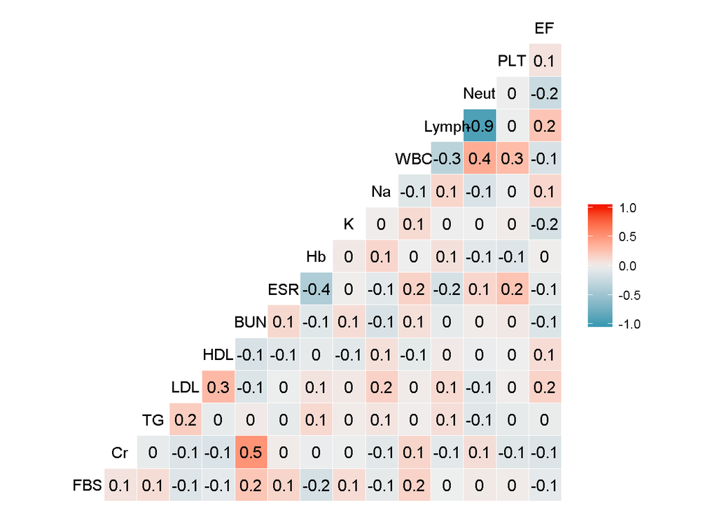

```r
library(GGally)

LABcor3 <- ggcorr(LABB4[1:15], palette = "RdY1Gn", label = TRUE)
LABcor3
```

#### Looking into the Neutrophil to Lymphocyte relationship further. Calculating the NLR (neutrophil-lymphocyte ratio) below. Reference # 24 shows that they have identified that the normal NLR values in an adult, non-geriatric, population in good health are between 0.78 and 3.53.

```r
NLR <- data.frame(FullSetB42[48:47])
NLR$Ratio <- NLR$Neut/NLR$Lymph

min(NLR$Ratio)
```

```
## [1] 0.5689655
```

```r
max(NLR$Ratio)
```

```
## [1] 12.14286
```

```r
mean(NLR$Ratio)
```

```
## [1] 2.244218
```

```r
NLR$Result <- cut(NLR$Ratio, breaks = c(0,0.77,3.53,12.5), labels = c("Low", "Med", "High"))

NLR$CAD <- FullSetB42$CAD

NLRlow <- sum(NLR$Result == "Low")
NLRlow
```

```
## [1] 10
```

```r
NLRmed <- sum(NLR$Result == "Med")
NLRmed
```

```
## [1] 257
```

```r
NLRhigh <- sum(NLR$Result == "High")
NLRhigh
```

```
## [1] 36
```

```r
NLRcount <- sum(NLRlow+NLRmed+NLRhigh)
NLRcount
```

```
## [1] 303
```

#### Include remaining numeric attributes for further correlation overview: Shows no significant correlation results, other than what was already found:

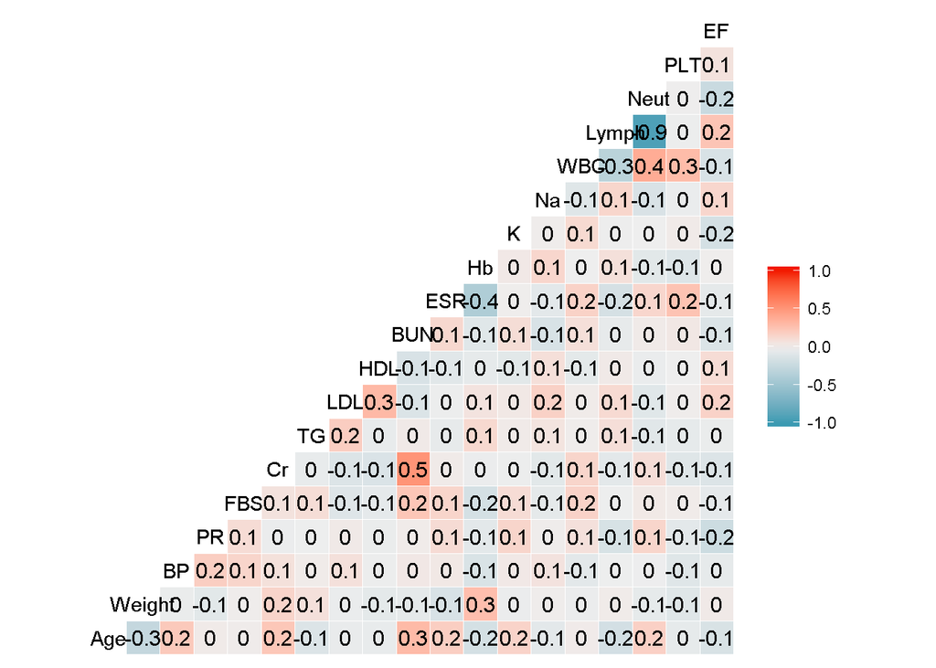

```r
library(GGally)

Allints1 <- ggcorr(FullSetB42[,c(1:2, 16:17, 36:50)], palette = "RdY1Gn", label = TRUE)
Allints1
```

#### Boxplot of Low Density Lipoprotein (LDL), High Density Lipoprotein (HDL), Blood Urea Nitrogen (BUN), and Erythrocyte Sedimentation Rate (ESR):

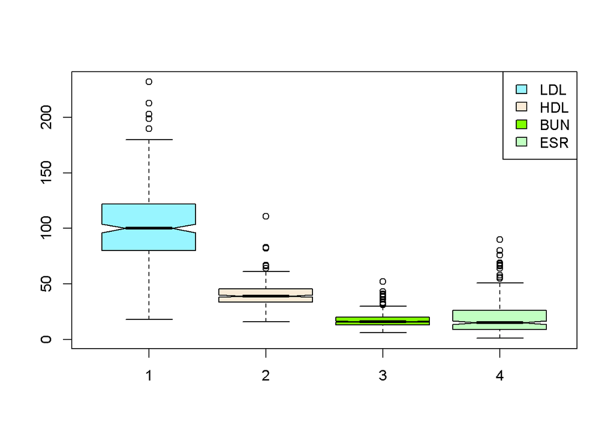

```r
attach(LABB4)
boxplot(LDL, HDL, BUN, ESR, col = c("cadetblue1", "antiquewhite", "chartreuse", "darkseagreen1"), notch = TRUE, horizontal = FALSE, outline = TRUE, plot = TRUE)
legend("topright", c("LDL", "HDL", "BUN", "ESR"),fill = c("cadetblue1", "antiquewhite", "chartreuse", "darkseagreen1"))
```

#### Boxplot of Sodium (Na), Lymphocyte % (Lymph), Neutrophil % (Neut), and Ejection Fraction % (EF):

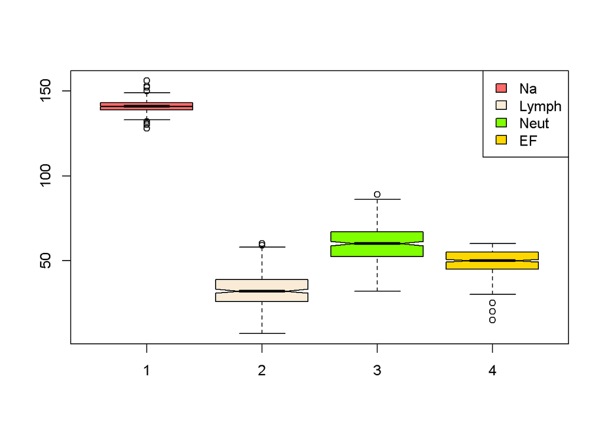

```r
boxplot(Na, Lymph, Neut, EF, col = c("indianred1", "antiquewhite", "chartreuse", "gold"), notch = TRUE, horizontal = FALSE, outline = TRUE, plot = TRUE)
legend("topright", c("Na", "Lymph", "Neut", "EF"),fill = c("indianred1", "antiquewhite", "chartreuse", "gold"))
```

#### Boxplot of Triglyceride (TG), Platelet (PLT), and Fasting Blood Sugar (FBS):

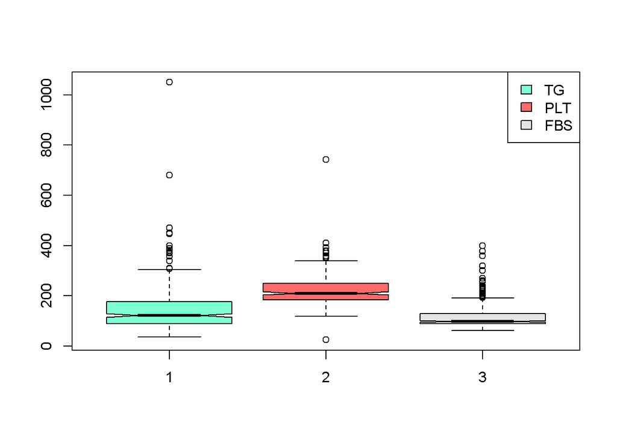

```r
boxplot(TG, PLT, FBS, col = c("aquamarine","indianred1", "gray90"), notch = TRUE, horizontal = FALSE, outline = TRUE, plot = TRUE)
legend("topright", c("TG", "PLT", "FBS"),fill = c("aquamarine","indianred1", "gray90"))
```

#### Boxplot of Hemoglobin (Hb), Potassium (K), and Creatine (Cr):

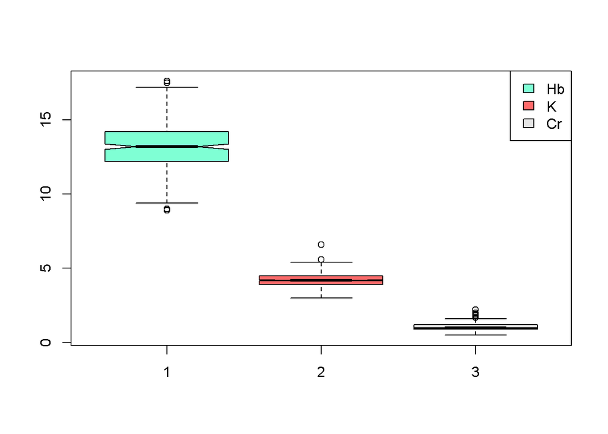

```r
boxplot(Hb, K, Cr, col = c("aquamarine","indianred1", "gray90"), notch = TRUE, horizontal = FALSE, outline = TRUE, plot = TRUE)
legend("topright", c("Hb", "K", "Cr"),fill = c("aquamarine","indianred1", "gray90"))
```

#### Boxplot of White Blood Cell (WBC) count:

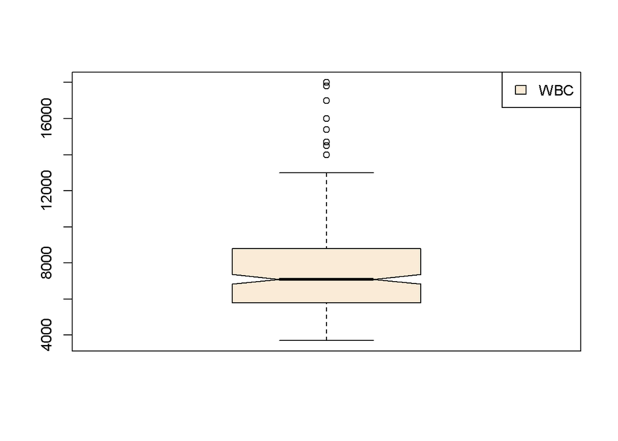

```r
boxplot(WBC, col = c("antiquewhite"), notch = TRUE, horizontal = FALSE, outline = TRUE, plot = TRUE)
legend("topright", c("WBC"),fill = c("antiquewhite"))
```

#### Boxplot to show distribution of Age and Weight:

```r
attach(DemoB4)
```

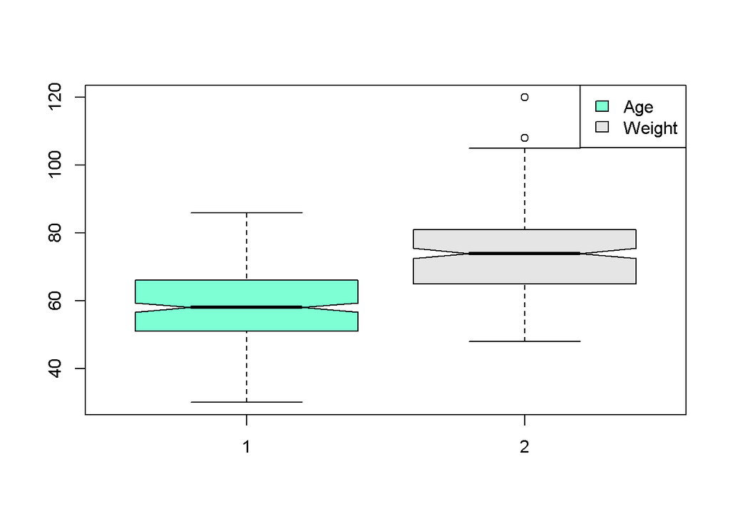

```r
boxplot(Age, Weight, col = c("aquamarine","gray90"), notch = TRUE, horizontal = FALSE, outline = TRUE, plot = TRUE)
legend("topright", c("Age", "Weight"),fill = c("aquamarine","gray90"))
```

#### Shapiro tests of normality (H0: Distribution is normal; Reject null if p-value is less than .05). Note: sensitive when n>80. This test shows that ‘Age’ is NOT normally distributed.

```r
library(psych)
describe(DemoB4$Age)
```

```
##    vars   n mean    sd median trimmed   mad min max range skew kurtosis
## X1    1 303 58.9 10.39     58   58.68 11.86  30  86    56 0.13    -0.44
##     se
## X1 0.6
```

```r
AgeNorm <- shapiro.test((DemoB4$Age))
AgeNorm
```

```
##
##  Shapiro-Wilk normality test
##
## data:  (DemoB4$Age)
## W = 0.98974, p-value = 0.03162
```

#### Hence, weight is also not normally distributed in this study.

```r
library(psych)

describe(DemoB4$Weight)
```

```
##    vars   n  mean    sd median trimmed   mad min max range skew kurtosis
## X1    1 303 73.83 11.99     74   73.44 11.86  48 120    72 0.41      0.3
##      se
## X1 0.69
```

```r
WeightNorm <- shapiro.test((DemoB4$Weight))
WeightNorm
```

```
##
##  Shapiro-Wilk normality test
##
## data:  (DemoB4$Weight)
## W = 0.98702, p-value = 0.007982
```

#### And BMI is also not normally distributed.

```r
describe(Allv1$BMI)
```

```
##    vars   n  mean  sd median trimmed  mad   min  max range skew kurtosis
## X1    1 303 27.25 4.1  26.78   27.07 3.77 18.12 40.9 22.79 0.43     0.11
##      se
## X1 0.24
```

```r
BMINorm <- shapiro.test((Allv1$BMI))
BMINorm
```

```
##
##  Shapiro-Wilk normality test
##
## data:  (Allv1$BMI)
## W = 0.98564, p-value = 0.004061
```

#### Can (carefully) use ‘describe’ for categorical variables too (since the psych package recodes categories as numbers):

```r
library(psych)
describe(FullSetB42[1:17])
```

```
##          vars   n   mean    sd median trimmed   mad min max range  skew
## Age         1 303  58.90 10.39     58   58.68 11.86  30  86    56  0.13
## Weight      2 303  73.83 11.99     74   73.44 11.86  48 120    72  0.41
## Sex*        3 303   1.58  0.49      2    1.60  0.00   1   2     1 -0.33
## DM          4 303   0.30  0.46      0    0.25  0.00   0   1     1  0.88
## HTN         5 303   0.59  0.49      1    0.61  0.00   0   1     1 -0.37
## Smoker      6 303   0.21  0.41      0    0.14  0.00   0   1     1  1.43
## ExSmoker    7 303   0.03  0.18      0    0.00  0.00   0   1     1  5.20
## FH          8 303   0.16  0.37      0    0.07  0.00   0   1     1  1.86
## Obesity*    9 303   1.70  0.46      2    1.74  0.00   1   2     1 -0.85
## CRF*       10 303   1.02  0.14      1    1.00  0.00   1   2     1  6.86
## CVA*       11 303   1.02  0.13      1    1.00  0.00   1   2     1  7.55
## AD*        12 303   1.04  0.19      1    1.00  0.00   1   2     1  4.93
## TD*        13 303   1.02  0.15      1    1.00  0.00   1   2     1  6.32
## CHF*       14 303   1.00  0.06      1    1.00  0.00   1   2     1 17.23
## DLP*       15 303   1.37  0.48      1    1.34  0.00   1   2     1  0.54
## BP         16 303 129.55 18.94    130  128.46 14.83  90 190   100  0.57
## PR         17 303  75.14  8.91     70   74.22  7.41  50 110    60  1.07
##          kurtosis   se
## Age         -0.44 0.60
## Weight       0.30 0.69
## Sex*        -1.90 0.03
## DM          -1.22 0.03
## HTN         -1.87 0.03
## Smoker       0.05 0.02
## ExSmoker    25.15 0.01
## FH           1.47 0.02
## Obesity*    -1.28 0.03
## CRF*        45.20 0.01
## CVA*        55.23 0.01
## AD*         22.41 0.01
## TD*         38.04 0.01
## CHF*       296.02 0.00
## DLP*        -1.72 0.03
## BP           0.48 1.09
## PR           2.33 0.51
```

#### Boxplot to show distribution of Blood Pressure and Pulse Rate

```r
attach(SymptomB4)
```

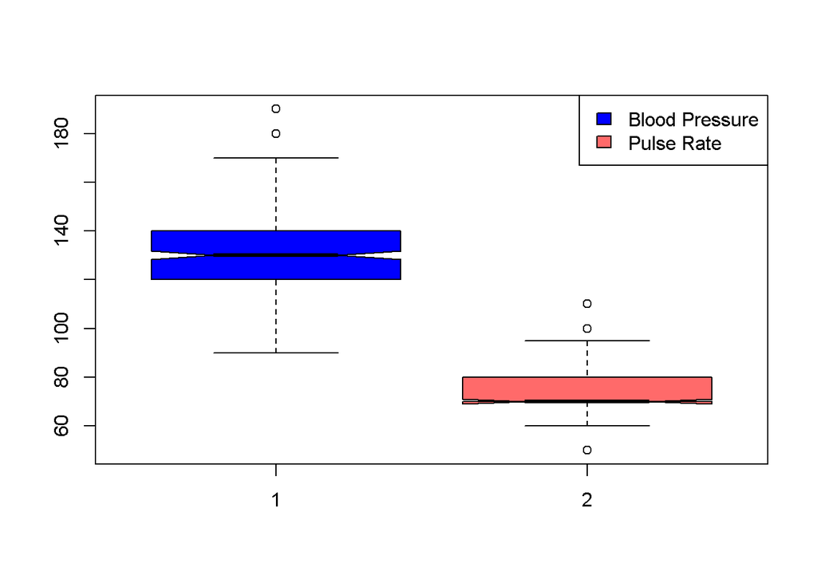

```r
boxplot(BP, PR, col = c("blue","indianred1"), notch = TRUE, horizontal = FALSE, outline = TRUE, plot = TRUE)
legend("topright", c("Blood Pressure", "Pulse Rate"),fill = c("blue","indianred1"))
```

#### Blood Pressure (BP) is not normally distributed:

```r
describe(SymptomB4$BP)
```

```
##    vars   n   mean    sd median trimmed   mad min max range skew kurtosis
## X1    1 303 129.55 18.94    130  128.46 14.83  90 190   100 0.57     0.48
##      se
## X1 1.09
```

```r
BPNorm <- shapiro.test((SymptomB4$BP))
BPNorm
```

```
##
##  Shapiro-Wilk normality test
##
## data:  (SymptomB4$BP)
## W = 0.9543, p-value = 4.039e-08
```

#### Pulse Rate is not normally distributed:

```r
describe(SymptomB4$PR)
```

```
##    vars   n  mean   sd median trimmed  mad min max range skew kurtosis
## X1    1 303 75.14 8.91     70   74.22 7.41  50 110    60 1.07     2.33
##      se
## X1 0.51
```

```r
PRNorm <- shapiro.test((SymptomB4$PR))
PRNorm
```

```
##
##  Shapiro-Wilk normality test
##
## data:  (SymptomB4$PR)
## W = 0.86016, p-value = 6.633e-16
```

#### Density plot of weight and sex (before discretization):

```r
library(ggplot2)
library(dplyr)
library(plyr)

WeightMu <- ddply(DemoB4, "Sex", summarise, grp.mean=mean(Weight))
head(WeightMu)
```

```
##     Sex grp.mean
## 1 Fmale 70.52756
## 2  Male 76.21591
```

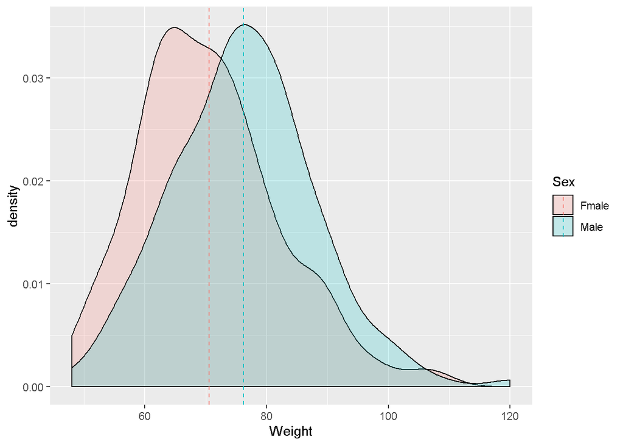

```r
DDen1 <- ggplot(DemoB4, aes(x = Weight, fill = Sex)) +
  geom_density(alpha = 0.2)+
  geom_vline(data = WeightMu, aes(xintercept=grp.mean, colour = Sex),
             linetype = "dashed")
DDen1
```

#### Density plot of BMI and sex (before discretization):

```r
BMIMu <- ddply(Allv1, "Sex", summarise, grp.mean=mean(BMI))
head(BMIMu)
```

```
##     Sex grp.mean
## 1 Fmale 28.61687
## 2  Male 26.26082
```

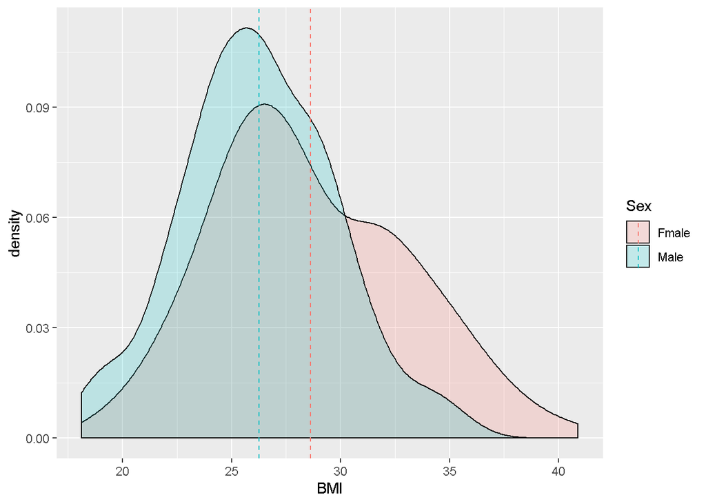

```r
BMIden <- ggplot(Allv1, aes(x = BMI, fill = Sex)) +
  geom_density(alpha = 0.2)+
  geom_vline(data = BMIMu, aes(xintercept=grp.mean, colour = Sex),
             linetype = "dashed")
BMIden
```

#### Starting with Diabetes (DM) and Hypertension (HTN): Shows small association

```r
library(lsr)

AllCatB4 <- Allv2[,c(3:15, 18:24,26:35)]
cramersV(AllCatB4$DM, AllCatB4$HTN)
```

```
## [1] 0.2105191
```

#### Ex-Smoker and Obesity shows no association:

```r
cramersV(AllCatB4$ExSmoker,AllCatB4$Obesity)
```

```
## [1] 0.02154688
```

```r
cramersV(AllCatB4$DM,AllCatB4$Obesity)
```

```
## [1] 0.01298559
```

#### Hypertensin and current smoker has a small association:

```r
cramersV(AllCatB4$HTN,AllCatB4$Smoker)
```

```
## [1] 0.1607305
```

#### Hypertension and Stroke (CVA) has no association:

```r
cramersV(AllCatB4$HTN,AllCatB4$CVA)
```

```
## [1] 0.02877846
```

#### Congestive Heart Failure (CHF) and Obsesity has no association (see below):

```r
cramersV(AllCatB4$CHF,AllCatB4$Obesity)
```

```
## [1] 1.5974e-15
```

#### Determining whether there is any significant variation in the ‘NCP’ column: Very low variation (94.7% of NCP entries are ‘No’)

```r
NCPn <- sum(FullSetB42$NCP == 'N')
NCPy <- sum(FullSetB42$NCP == 'Y')
(NCPn/(NCPn+NCPy))*100
```

```
## [1] 94.71947
```

#### Determining whether there is any significant variation in the ‘ACP’ column: 69.3% of these ‘ACP’ entries are ‘No’

```r
ACPn <- sum(FullSetB42$ACP == 'N')
ACPy <- sum(FullSetB42$ACP == 'Y')
(ACPn/(ACPn+ACPy))*100
```

```
## [1] 69.30693
```

#### Barplot of BBB attribute

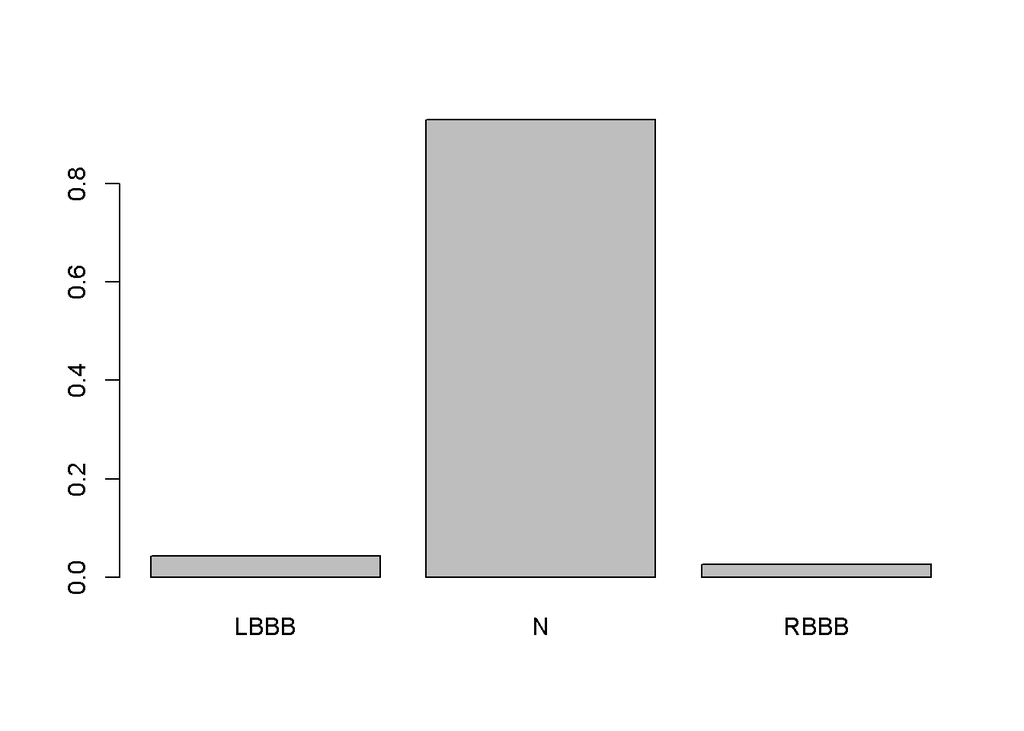

```r
barplot(prop.table(table(FullSetB42$BBB)))
```

#### Barplot of VHD attribute

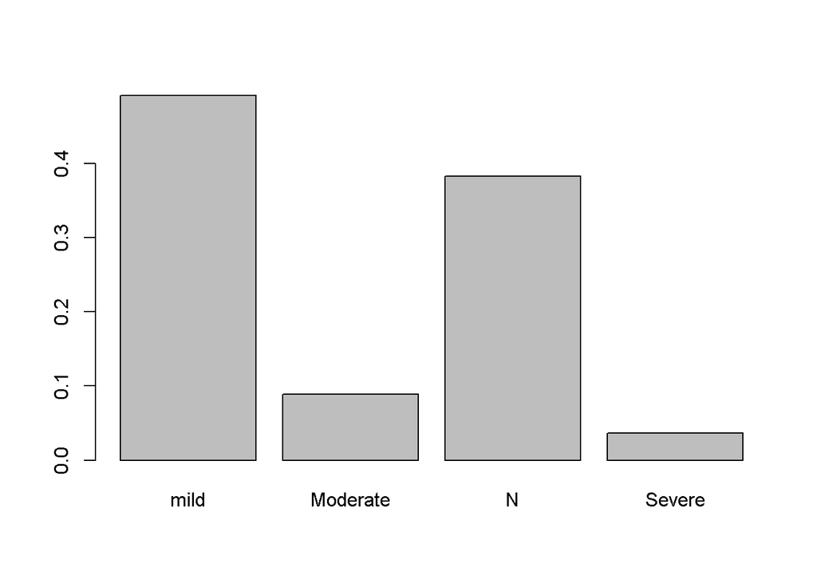

```r
barplot(prop.table(table(FullSetB42$VHD)))
```

### Feature selection on all the attributes combined, as well as on the 4 individual attribute groups - using the FSelector package:

#### Starting with the full data set - selected: CAD ~ TCP + ACP + RWMA + EF + Age + HTN + NCP + DM + Tinv + VHD

```r
library(FSelector)

AllWeights <- chi.squared(CAD~.,AllvFinal)
print(AllWeights)
```

```
##          attr_importance
## Age          0.290317717
## Weight       0.053693554
## Sex          0.067041240
## DM           0.252897001
## HTN          0.287760932
## Smoker       0.073503651
## ExSmoker     0.035578171
## FH           0.035605456
## Obesity      0.022461339
## CRF          0.090204905
## CVA          0.024945620
## AD           0.084178945
## TD           0.048077279
## CHF          0.036519875
## DLP          0.012718268
## BP           0.135498540
## PR           0.073888082
## Edema        0.054069268
## WPP          0.082207155
## LR           0.045178608
## SysM         0.004856462
## DiaM         0.146777311
## TCP          0.542966708
## Dyspnea      0.125210904
## Fclass       0.085918550
## ACP          0.415921817
## NCP          0.274183618
## LTAng        0.051732623
## QWave        0.149848291
## STelev       0.139684381
## STdep        0.144425871
## Tinv         0.236932878
## LVH          0.051196374
## PoorR        0.111040227
## BBB          0.088749817
## FBS          0.229347982
## Cr           0.102491681
## TG           0.086830465
## LDL          0.014501583
## HDL          0.015804598
## BUN          0.091662224
## ESR          0.065213016
## Hb           0.048994402
## K            0.069632280
## Na           0.067555843
## WBC          0.105345858
## Lymph        0.129137722
## Neut         0.106735676
## PLT          0.100855982
## EF           0.329842476
## RWMA         0.334812718
## VHD          0.231208043
```

```r
subset <- cutoff.k(AllWeights, 10)
FSall <- as.simple.formula(subset, "CAD")
print(FSall)
```

```
## CAD ~ TCP + ACP + RWMA + EF + Age + HTN + NCP + DM + Tinv + VHD
## <environment: 0x00000000210fa4d8>
```

#### Next, using the ‘Demo’ (Demographic) attribute data set - results: CAD ~ Age + HTN + DM + CRF + AD

```r
DemoWeights <- chi.squared(CAD~.,Demo)
print(DemoWeights)
```

```
##          attr_importance
## Age           0.29031772
## Weight        0.05369355
## Sex           0.06704124
## DM            0.25289700
## HTN           0.28776093
## Smoker        0.07350365
## ExSmoker      0.03557817
## FH            0.03560546
## Obesity       0.02246134
## CRF           0.09020490
## CVA           0.02494562
## AD            0.08417894
## TD            0.04807728
## CHF           0.03651987
## DLP           0.01271827
```

```r
subset <- cutoff.k(DemoWeights, 5)
FSdemo <- as.simple.formula(subset, "CAD")
print(FSdemo)
```

```
## CAD ~ Age + HTN + DM + CRF + AD
## <environment: 0x0000000022c36ba8>
```

#### Next, using the ‘Symptom’ (Symptom & Examination) attribute data set - results: CAD ~ TCP + ACP + NCP + DiaM + BP

```r
SymWeights <- chi.squared(CAD~.,Symptom)
print(SymWeights)
```

```
##         attr_importance
## BP          0.135498540
## PR          0.073888082
## Edema       0.054069268
## WPP         0.082207155
## LR          0.045178608
## SysM        0.004856462
## DiaM        0.146777311
## TCP         0.542966708
## Dyspnea     0.125210904
## Fclass      0.085918550
## ACP         0.415921817
## NCP         0.274183618
## LTAng       0.051732623
```

```r
subset <- cutoff.k(SymWeights, 5)
FSsym <- as.simple.formula(subset, "CAD")
print(FSsym)
```

```
## CAD ~ TCP + ACP + NCP + DiaM + BP
## <environment: 0x000000001dde43d0>
```

#### Next, using the ’ECG’attribute data set - results: CAD ~ Tinv + QWave + STdep + STelev + PoorR

```r
ECGWeights <- chi.squared(CAD~.,ECG)
print(ECGWeights)
```

```
##        attr_importance
## QWave       0.14984829
## STelev      0.13968438
## STdep       0.14442587
## Tinv        0.23693288
## LVH         0.05119637
## PoorR       0.11104023
## BBB         0.08874982
```

```r
subset <- cutoff.k(ECGWeights, 5)
FSecg <- as.simple.formula(subset, "CAD")
print(FSecg)
```

```
## CAD ~ Tinv + QWave + STdep + STelev + PoorR
## <environment: 0x000000001b84a750>
```

#### Lastly, using the ‘LAB’ (Laboratory and Echocardiographic) attribute data set - results: CAD ~ RWMA + EF + VHD + FBS + Lymph

```r
LABWeights <- chi.squared(CAD~.,LAB)
print(LABWeights)
```

```
##       attr_importance
## FBS        0.22934798
## Cr         0.10249168
## TG         0.08683046
## LDL        0.01450158
## HDL        0.01580460
## BUN        0.09166222
## ESR        0.06521302
## Hb         0.04899440
## K          0.06963228
## Na         0.06755584
## WBC        0.10534586
## Lymph      0.12913772
## Neut       0.10673568
## PLT        0.10085598
## EF         0.32984248
## RWMA       0.33481272
## VHD        0.23120804
```

```r
subset <- cutoff.k(LABWeights, 5)
FSlab <- as.simple.formula(subset, "CAD")
print(FSlab)
```

```
## CAD ~ RWMA + EF + VHD + FBS + Lymph
## <environment: 0x0000000020b6bf78>
```

### Now, comparing these discretized results with those from before discretization:

#### Using the full data set (FullSetB42) - results: CAD ~ TCP + ACP + RWMA + EF + Age + HTN + *BP* + NCP + DM + *FBS* (while the discretized results were: CAD ~ TCP + ACP + RWMA + EF + Age + HTN + NCP + DM + Tinv + VHD). NOTE: The top 6 were the same for both data sets (and 8 of the top 10 were shared across both data sets)

```r
AllB4Weights <- chi.squared(CAD~.,FullSetB42)
print(AllB4Weights)
```

```
##          attr_importance
## Age          0.328281473
## Weight       0.000000000
## Sex          0.067041240
## DM           0.252897001
## HTN          0.287760932
## Smoker       0.000000000
## ExSmoker     0.000000000
## FH           0.000000000
## Obesity      0.022461339
## CRF          0.090204905
## CVA          0.024945620
## AD           0.084178945
## TD           0.048077279
## CHF          0.036519875
## DLP          0.012718268
## BP           0.275203095
## PR           0.000000000
## Edema        0.000000000
## WPP          0.082207155
## LR           0.045178608
## SysM         0.004856462
## DiaM         0.146777311
## TCP          0.542966708
## Dyspnea      0.125210904
## Fclass       0.000000000
## ACP          0.415921817
## NCP          0.274183618
## LTAng        0.051732623
## QWave        0.000000000
## STelev       0.000000000
## STdep        0.000000000
## Tinv         0.236932878
## LVH          0.051196374
## PoorR        0.111040227
## BBB          0.088749817
## FBS          0.238635213
## Cr           0.000000000
## TG           0.000000000
## LDL          0.000000000
## HDL          0.000000000
## BUN          0.000000000
## ESR          0.000000000
## Hb           0.000000000
## K            0.000000000
## Na           0.000000000
## WBC          0.000000000
## Lymph        0.000000000
## Neut         0.000000000
## PLT          0.000000000
## EF           0.329842476
## RWMA         0.334812718
## VHD          0.231208043
```

```r
subset <- cutoff.k(AllB4Weights, 10)
FSB4all <- as.simple.formula(subset, "CAD")
print(FSB4all)
```

```
## CAD ~ TCP + ACP + RWMA + EF + Age + HTN + BP + NCP + DM + FBS
## <environment: 0x000000001dd2dce8>
```

#### Comparing the discretized feature selection results found using the ‘FSelector’ package with the results using the ‘FSelectorRcpp’ package - results: CAD ~ TCP + ACP + RWMA + EF + HTN + Age + DM + NCP + Tinv + FBS

```r
library(FSelectorRcpp)
library(tidyverse)

FS2all <- information_gain(
  formula = CAD~.,
  data = AllvFinal,
  type = "infogain",
  threads = 2
) %>%
cut_attrs(
  k = 10
) %>%
to_formula(
  attrs = .,
  class = "CAD"
)
print(FS2all)
```

```
## CAD ~ TCP + ACP + RWMA + EF + HTN + Age + DM + NCP + Tinv + FBS
## <environment: 0x000000001d40d700>
```

#### Lastly, comparing the output of the FSelectorRcpp package using the data set that was not discretized yet (FullSetB42 data set) - result: CAD ~ TCP + ACP + RWMA + Age + EF + HTN + DM + BP + NCP + Tinv

```r
FS2B4all <- information_gain(
  formula = CAD~.,
  data = FullSetB42,
  type = "infogain",
  threads = 2
) %>%
cut_attrs(
  k = 10
) %>%
to_formula(
  attrs = .,
  class = "CAD"
)
print(FS2B4all)
```

```
## CAD ~ TCP + ACP + RWMA + Age + EF + HTN + DM + BP + NCP + Tinv
## <environment: 0x000000001d13bed0>
```

#### Checking on strength of associations between top 12 attributes and the dependent variable, ranked in descending order:

```r
library(lsr)

cramersV(AllvFinal$TCP, AllvFinal$CAD)
```

```
## [1] 0.5356469
```

```r
cramersV(AllvFinal$ACP, AllvFinal$CAD)
```

```
## [1] 0.4080137
```

```r
cramersV(AllvFinal$RWMA, AllvFinal$CAD)
```

```
## [1] 0.3267227
```

```r
cramersV(AllvFinal$EF, AllvFinal$CAD)
```

```
## [1] 0.3221946
```

```r
cramersV(AllvFinal$Age, AllvFinal$CAD)
```

```
## [1] 0.2814322
```

```r
cramersV(AllvFinal$HTN, AllvFinal$CAD)
```

```
## [1] 0.2803429
```

```r
cramersV(AllvFinal$NCP, AllvFinal$CAD)
```

```
## [1] 0.2578747
```

```r
cramersV(AllvFinal$DM, AllvFinal$CAD)
```

```
## [1] 0.2449149
```

```r
cramersV(AllvFinal$VHD, AllvFinal$CAD)
```

```
## [1] 0.231208
```

```r
cramersV(AllvFinal$FBS, AllvFinal$CAD)
```

```
## [1] 0.229348
```

```r
cramersV(AllvFinal$Tinv, AllvFinal$CAD)
```

```
## [1] 0.2289508
```

```r
cramersV(AllvFinal$BP, AllvFinal$CAD)
```

```
## [1] 0.1255092
```

#### Checking on the strength of associations between the top 12 attributes and each other:

```r
cramersV(AllvFinal$TCP, AllvFinal$ACP)
```

```
## [1] 0.7156668
```

```r
cramersV(AllvFinal$HTN, AllvFinal$BP)
```

```
## [1] 0.3519147
```

```r
cramersV(AllvFinal$RWMA, AllvFinal$EF)
```

```
## [1] 0.269923
```

```r
cramersV(AllvFinal$TCP, AllvFinal$NCP)
```

```
## [1] 0.2416607
```

```r
cramersV(AllvFinal$HTN, AllvFinal$DM)
```

```
## [1] 0.2105191
```

```r
cramersV(AllvFinal$VHD, AllvFinal$Age)
```

```
## [1] 0.1636751
```

```r
cramersV(AllvFinal$RWMA, AllvFinal$TCP)
```

```
## [1] 0.1608916
```

```r
cramersV(AllvFinal$HTN, AllvFinal$VHD)
```

```
## [1] 0.1379553
```

```r
cramersV(AllvFinal$Tinv, AllvFinal$EF)
```

```
## [1] 0.1360726
```

```r
cramersV(AllvFinal$TCP, AllvFinal$Age)
```

```
## [1] 0.1078061
```

```r
cramersV(AllvFinal$RWMA, AllvFinal$Age)
```

```
## [1] 0.1060843
```

```r
cramersV(AllvFinal$HTN, AllvFinal$Age)
```

```
## [1] 0.09646362
```

#### Checking associations between the final variables that do not have a statistically significant relationship with the dependent variable (per the logistic regression results later). That is, checkint ACP and NCP against each other, and the other variables, including TCP, EF, RWMA, HTN, Age and DM (as well as the dependent variable). NOTE: When DF=1, the interpretation of the Cramer’s V results (effect) would be as follows: (0.10 = small effect) (0.30 = medium effect) (0.50=large effect)

```r
library(lsr)

cramersV(AllvFinal$ACP, AllvFinal$TCP)
```

```
## [1] 0.7156668
```

```r
cramersV(AllvFinal$ACP, AllvFinal$EF)
```

```
## [1] 0.1645235
```

```r
cramersV(AllvFinal$ACP, AllvFinal$RWMA)
```

```
## [1] 0.1729343
```

```r
cramersV(AllvFinal$ACP, AllvFinal$HTN)
```

```
## [1] 0.1373895
```

```r
cramersV(AllvFinal$ACP, AllvFinal$Age)
```

```
## [1] 0.1141707
```

```r
cramersV(AllvFinal$ACP, AllvFinal$DM)
```

```
## [1] 0.08023603
```

```r
cramersV(AllvFinal$ACP, AllvFinal$CAD)
```

```
## [1] 0.4080137
```

```r
cramersV(AllvFinal$NCP, AllvFinal$TCP)
```

```
## [1] 0.2416607
```

```r
cramersV(AllvFinal$NCP, AllvFinal$EF)
```

```
## [1] 0.05887248
```

```r
cramersV(AllvFinal$NCP, AllvFinal$RWMA)
```

```
## [1] 0.0668128
```

```r
cramersV(AllvFinal$NCP, AllvFinal$HTN)
```

```
## [1] 0.001436249
```

```r
cramersV(AllvFinal$NCP, AllvFinal$Age)
```

```
## [1] 0.03838205
```

```r
cramersV(AllvFinal$NCP, AllvFinal$DM)
```

```
## [1] 0.07274291
```

```r
cramersV(AllvFinal$NCP, AllvFinal$CAD)
```

```
## [1] 0.2578747
```

#### Creating the final variable data set using the FSelector package:

```r
TenVars <- AllvFinal[, c("TCP", "ACP", "RWMA", "EF", "Age", "HTN", "NCP", "DM", "Tinv", "VHD", "CAD")]
#TenVars
```

#### Creating a second final variable data set using the FSelectorRcpp package:

```r
TenVars2 <- AllvFinal[, c("TCP", "ACP", "RWMA", "EF", "HTN", "Age", "DM", "NCP", "Tinv", "FBS", "CAD")]
#TenVars2
```

#### Checking on feature selection using the (hybrid) Autospearman function: Currently UNABLE to install Rnalyica package - and hence cannot find/load ‘AutoSpearman’ function. Installation corrupted system.

#### Using createDataPartition() to split data into training and test sets (75% and 25%). Since the outcome variable (CAD) is categorical, this function will make sure that the distribution of outcome variable classes will be similar in both of the sets.

```r
library(caret)

#index <- createDataPartition(AllvFinal$CAD, p = 0.75, list = FALSE)
#AllvFtrain <- AllvFinal[ index,]
#AllvFtest <- AllvFinal[-index,]
```

#### Saved off resulting train and test files for retrieval for subsequent algorithms, etc. This is to ensure that the same training/test split files are used before the recursive feature elimination, cross validation, training and running of algorithms.

```r
AllvFtrain<-read.csv(file="https://raw.githubusercontent.com/ToddB11/TB136capstone/master/AllvFtrainCopy.csv",header=T,sep=",")

AllvFtest<-read.csv(file="https://raw.githubusercontent.com/ToddB11/TB136capstone/master/AllvFtestCopy.csv",header=T,sep=",")
```

#### Using ‘Recursive Feature Elimination’ to find the best subset of atttributes to use for modeling.

```r
library(plyr)

control <- rfeControl(functions = rfFuncs,
                   method = "repeatedcv",
                   repeats = 10,
                   verbose = FALSE)
outcomeName <- 'CAD'
predictors <- names(AllvFtrain)[!names(AllvFtrain) %in% outcomeName]
CAD_Profile <- rfe(AllvFtrain[,predictors], AllvFtrain[,outcomeName],
                   rfeControl = control)

CAD_Profile
```

```
##
## Recursive feature selection
##
## Outer resampling method: Cross-Validated (10 fold, repeated 10 times)
##
## Resampling performance over subset size:
##
##  Variables Accuracy  Kappa AccuracySD KappaSD Selected
##          4   0.7794 0.4660    0.09029  0.2285
##          8   0.8072 0.5113    0.08982  0.2303
##         16   0.8172 0.5464    0.07568  0.1864
##         52   0.8229 0.5508    0.07717  0.1940        *
##
## The top 5 variables (out of 52):
##    TCP, ACP, RWMA, EF, NCP
```

```r
CAD_Profile$optVariables[1:8]
```

```
## [1] "TCP"  "ACP"  "RWMA" "EF"   "NCP"  "Tinv" "Age"  "DM"
```

```r
predictors <-c("TCP", "EF", "RWMA", "NCP", "ACP", "HTN", "Age", "DM")
```

### Random Forest Training

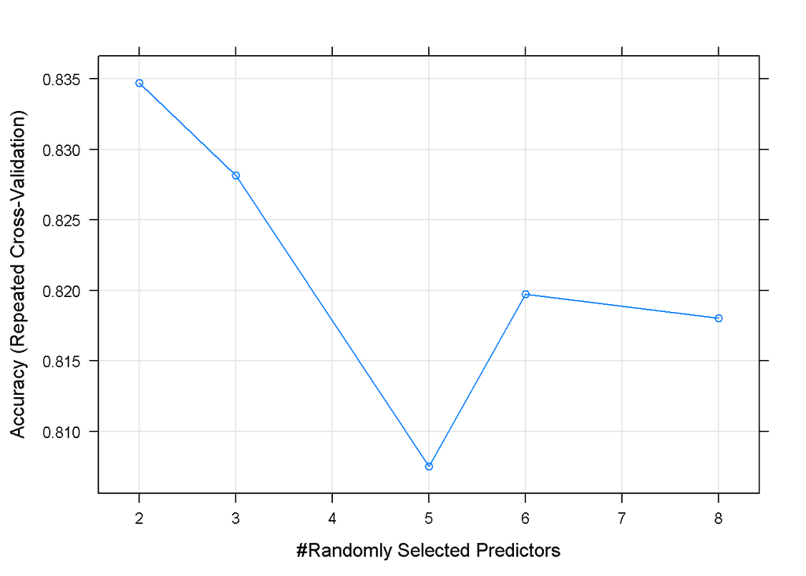

```r
library(tictoc)
library(caret)
library(DMwR)

tic("Random Forest Algorithm Timing")

rfFit <- train(AllvFtrain[,predictors], AllvFtrain[,outcomeName], method = 'rf', returnResamp = "final", tuneLength = 5, trControl = trainControl(method = "repeatedcv", number = 10, repeats = 10, sampling = "smote", allowParallel=TRUE))
rfFit
plot(rfFit)
```

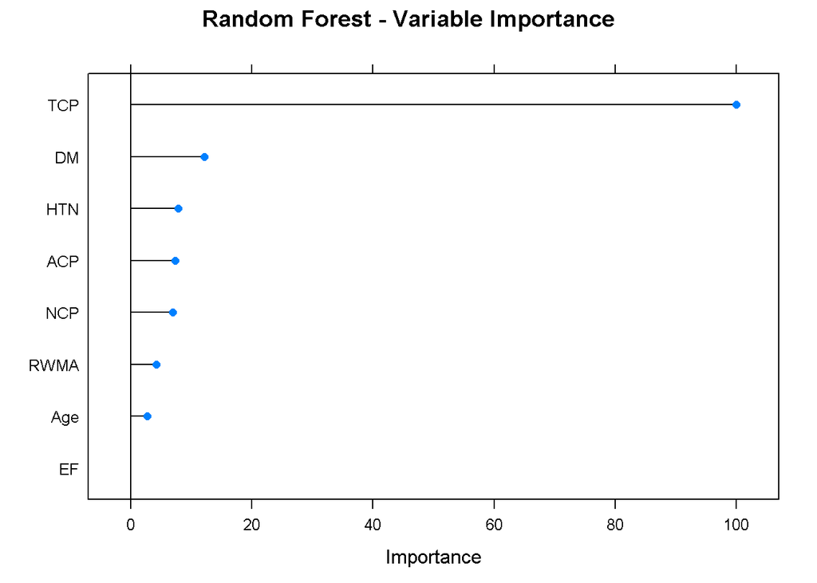

```r
varImp(object = rfFit)
plot(varImp(object = rfFit),main="Random Forest - Variable Importance")
```

#### Random Forest Predictions

```r
library(tidyverse)

RFpredictions <- predict.train(object = rfFit, AllvFtest[,predictors], type = "raw")
table(RFpredictions)
```

```
## RFpredictions
##    Cad Normal
##     52     23
```

```r
confusionMatrix(RFpredictions, AllvFtest[,outcomeName])
```

```
## Confusion Matrix and Statistics
##
##           Reference
## Prediction Cad Normal
##     Cad     50      2
##     Normal   4     19
##
##                Accuracy : 0.92
##                  95% CI : (0.834, 0.9701)
##     No Information Rate : 0.72
##     P-Value [Acc > NIR] : 1.76e-05
##
##                   Kappa : 0.8072
##
##  Mcnemar's Test P-Value : 0.6831
##
##             Sensitivity : 0.9259
##             Specificity : 0.9048
##          Pos Pred Value : 0.9615
##          Neg Pred Value : 0.8261
##              Prevalence : 0.7200
##          Detection Rate : 0.6667
##    Detection Prevalence : 0.6933
##       Balanced Accuracy : 0.9153
##
##        'Positive' Class : Cad
##
```

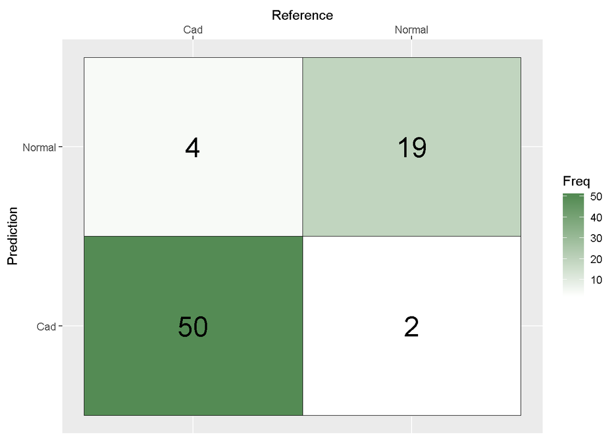

```r
RFcm <- confusionMatrix(RFpredictions, AllvFtest[,outcomeName], mode = 'everything')

RFcm$table %>%
  data.frame() %>%
  mutate(Prediction = factor(Prediction, levels = c("Cad", "Normal"))) %>%
  group_by(Reference) %>%
  mutate(total = sum(Freq)) %>%
  ungroup() %>%
  ggplot(aes(Reference, Prediction, fill = Freq)) +
  geom_tile() +
  geom_text(aes(label = Freq), size = 8) +
  scale_fill_gradient(low = "white", high = "palegreen4") +
  scale_x_discrete(position = "top") +
  geom_tile(color = "black", fill = "black", alpha = 0)
```

```r
toc()
```

```
## Random Forest Algorithm Timing: 73.4 sec elapsed
```

### Training for Naive Bayes:

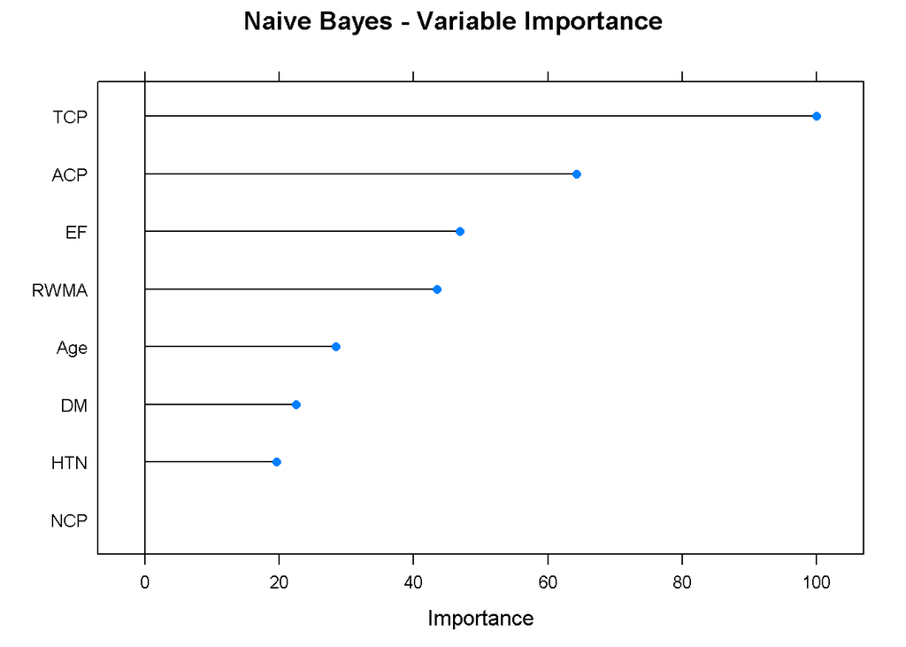

```r
library(klaR)
library(caret)

tic("Naive Bayes Algorithm Timing")

NBfit <- train(AllvFtrain[,predictors], AllvFtrain[,outcomeName], method = 'nb', returnResamp = "final", tuneLength = 5, trControl = trainControl(method = "repeatedcv", number = 10, repeats = 10, sampling = "smote", allowParallel=TRUE))
NBfit

varImp(object = NBfit)
plot(varImp(object = NBfit),main="Naive Bayes - Variable Importance")
```

#### Naive Bayes Predictions:

```r
NBpredictions <- predict.train(object = NBfit, AllvFtest[,predictors])
table(NBpredictions)
```

```
## NBpredictions
##    Cad Normal
##     47     28
```

```r
confusionMatrix(NBpredictions, AllvFtest[,outcomeName], mode = 'everything')
```

```
## Confusion Matrix and Statistics
##
##           Reference
## Prediction Cad Normal
##     Cad     47      0
##     Normal   7     21
##
##                Accuracy : 0.9067
##                  95% CI : (0.8171, 0.9616)
##     No Information Rate : 0.72
##     P-Value [Acc > NIR] : 7.087e-05
##
##                   Kappa : 0.7899
##
##  Mcnemar's Test P-Value : 0.02334
##
##             Sensitivity : 0.8704
##             Specificity : 1.0000
##          Pos Pred Value : 1.0000
##          Neg Pred Value : 0.7500
##               Precision : 1.0000
##                  Recall : 0.8704
##                      F1 : 0.9307
##              Prevalence : 0.7200
##          Detection Rate : 0.6267
##    Detection Prevalence : 0.6267
##       Balanced Accuracy : 0.9352
##
##        'Positive' Class : Cad
##
```

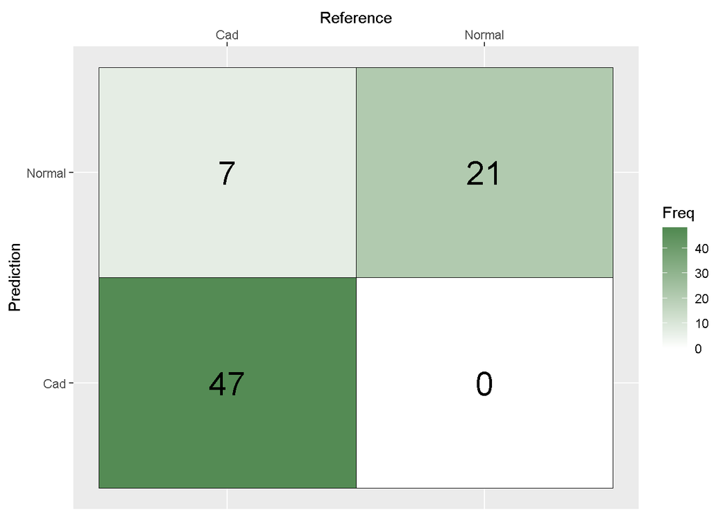

```r
NBcm <- confusionMatrix(NBpredictions, AllvFtest[,outcomeName])

NBcm$table %>%
  data.frame() %>%
  mutate(Prediction = factor(Prediction, levels = c("Cad", "Normal"))) %>%
  group_by(Reference) %>%
  mutate(total = sum(Freq)) %>%
  ungroup() %>%
  ggplot(aes(Reference, Prediction, fill = Freq)) +
  geom_tile() +
  geom_text(aes(label = Freq), size = 8) +
  scale_fill_gradient(low = "white", high = "palegreen4") +
  scale_x_discrete(position = "top") +
  geom_tile(color = "black", fill = "black", alpha = 0)
```

```r
toc()
```

```
## Naive Bayes Algorithm Timing: 8.72 sec elapsed
```

### Training for Logistic Regression:

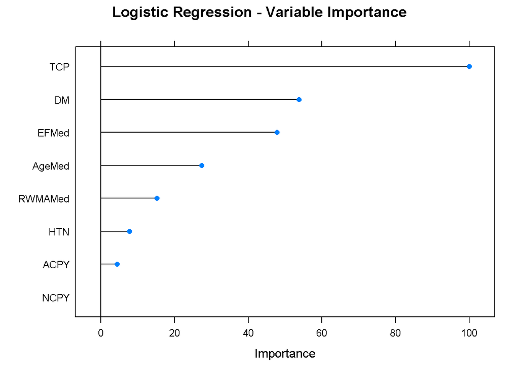

```r
tic("Logistic Regression Algorithm Timing")

LRFit <- train(AllvFtrain[,predictors], AllvFtrain[,outcomeName], method = 'glm', family = "binomial", tuneLength = 5, trControl = trainControl(method = "repeatedcv", number = 10, repeats = 10, sampling = "smote", allowParallel=TRUE))
LRFit

varImp(object = LRFit)
plot(varImp(object = LRFit), main="Logistic Regression - Variable Importance")
```

#### Logistic Regression Predictions:

```r
library(tidyverse)

LRpredictions <- predict.train(object = LRFit, AllvFtest[,predictors])
table(LRpredictions)
```

```
## LRpredictions
##    Cad Normal
##     50     25
```

```r
confusionMatrix(LRpredictions, AllvFtest[,outcomeName])
```

```
## Confusion Matrix and Statistics
##
##           Reference
## Prediction Cad Normal
##     Cad     49      1
##     Normal   5     20
##
##                Accuracy : 0.92
##                  95% CI : (0.834, 0.9701)
##     No Information Rate : 0.72
##     P-Value [Acc > NIR] : 1.76e-05
##
##                   Kappa : 0.8125
##
##  Mcnemar's Test P-Value : 0.2207
##
##             Sensitivity : 0.9074
##             Specificity : 0.9524
##          Pos Pred Value : 0.9800
##          Neg Pred Value : 0.8000
##              Prevalence : 0.7200
##          Detection Rate : 0.6533
##    Detection Prevalence : 0.6667
##       Balanced Accuracy : 0.9299
##
##        'Positive' Class : Cad
##
```

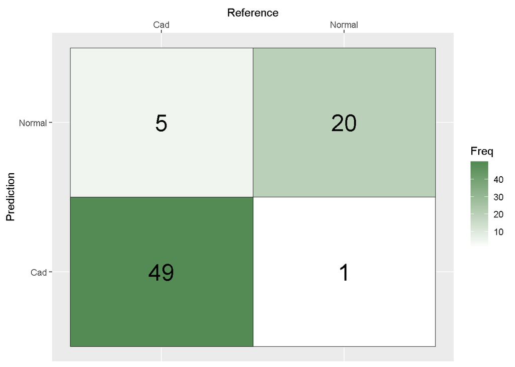

```r
LRcm <- confusionMatrix(LRpredictions, AllvFtest[,outcomeName], mode = 'everything')

LRcm$table %>%
  data.frame() %>%
  mutate(Prediction = factor(Prediction, levels = c("Cad", "Normal"))) %>%
  group_by(Reference) %>%
  mutate(total = sum(Freq)) %>%
  ungroup() %>%
  ggplot(aes(Reference, Prediction, fill = Freq)) +
  geom_tile() +
  geom_text(aes(label = Freq), size = 8) +
  scale_fill_gradient(low = "white", high = "palegreen4") +
  scale_x_discrete(position = "top") +
  geom_tile(color = "black", fill = "black", alpha = 0)
```

```r
toc()
```

```
## Logistic Regression Algorithm Timing: 4.31 sec elapsed
```

# Ensemble evaluation - work in progress

```r
library(caretEnsemble)

# Defining the training control:

ENCntrl <- trainControl(method = "repeatedcv", number = 10, repeats = 3, search = "grid", savePredictions = "final", sampling = "smote", classProbs = TRUE)

# Training the 3 models:

RFmodel <- train(AllvFtrain[,predictors],AllvFtrain[,outcomeName], method='rf',tuneLength = 3, trControl = ENCntrl)

NBmodel <- train(AllvFtrain[,predictors],AllvFtrain[,outcomeName], method='nb',tuneLength = 3, trControl = ENCntrl)

LRmodel <- train(AllvFtrain[,predictors],AllvFtrain[,outcomeName], method='glm',tuneLength = 3, trControl = ENCntrl)

RF_pred <- predict(object = RFmodel, AllvFtest[,predictors], type = 'raw')
NB_pred <- predict(object = NBmodel, AllvFtest[,predictors], type = 'raw')
LR_pred <- predict(object = LRmodel, AllvFtest[,predictors], type = 'raw')

confusionMatrix(RF_pred, AllvFtest[,outcomeName], mode = 'everything')
confusionMatrix(NB_pred, AllvFtest[,outcomeName], mode = 'everything')
confusionMatrix(LR_pred, AllvFtest[,outcomeName], mode = 'everything')
```

#### Ensamble evaluation:

```r
library(caretEnsemble)

ENCntrl <- trainControl(method = "repeatedcv", number = 10, repeats = 3, search = "grid", savePredictions = "final", sampling = "smote")

ENFit <- caretList(AllvFtrain[,predictors], AllvFtrain[,outcomeName], methodList = c("rf", "nb", "glm"))
ENFit

ENres <- resamples(ENFit)
summary(ENFit)
```

#### Model comparisons:

```r
#ModelCompare <- resamples(list(RF = rfFit, NB = NBfit, LR = LRFit))
#ModelCompare$values
#summary(ModelCompare)
```

#### Checking on the direction of log odds for a one unit increase in the selected features (using logistic regression) to confirm the relationship between the independent variables and the dependent variable (CAD or Normal):

```r
logiTrain <- data.frame(AllvFtrain[,c(23,51,27,26,50,1,5,4,53)])

logiTrain$CAD <- relevel(logiTrain$CAD, ref = "Normal")
str(logiTrain)
```

```
## 'data.frame':    228 obs. of  9 variables:
##  $ TCP : int  1 1 0 1 1 1 0 0 0 1 ...
##  $ RWMA: Factor w/ 2 levels "High","Med": 1 1 2 1 1 1 1 2 2 2 ...
##  $ NCP : Factor w/ 2 levels "N","Y": 1 1 2 1 1 1 1 1 1 1 ...
##  $ ACP : Factor w/ 2 levels "N","Y": 1 1 1 1 1 1 2 2 2 1 ...
##  $ EF  : Factor w/ 2 levels "Low","Med": 1 1 2 1 1 1 1 2 2 2 ...
##  $ Age : Factor w/ 2 levels "High","Med": 1 1 1 1 1 1 1 1 1 1 ...
##  $ HTN : int  1 0 1 0 0 0 1 1 0 1 ...
##  $ DM  : int  0 0 0 0 1 1 1 1 0 1 ...
##  $ CAD : Factor w/ 2 levels "Normal","Cad": 2 2 1 2 2 2 2 2 1 2 ...
```

```r
LRlogit <- glm(CAD~.,logiTrain, family = "binomial")
summary(LRlogit)
```

```
##
## Call:
## glm(formula = CAD ~ ., family = "binomial", data = logiTrain)
##
## Deviance Residuals:
##     Min       1Q   Median       3Q      Max
## -2.6427  -0.3298   0.1031   0.3794   2.0424
##
## Coefficients:
##             Estimate Std. Error z value Pr(>|z|)
## (Intercept)   1.8295     0.8946   2.045  0.04085 *
## TCP           3.4047     0.7646   4.453 8.46e-06 ***
## RWMAMed      -2.6388     0.8328  -3.169  0.00153 **
## NCPY         -1.4209     1.0783  -1.318  0.18757
## ACPY          0.4693     0.6646   0.706  0.48012
## EFMed        -1.5196     0.4668  -3.256  0.00113 **
## AgeMed       -1.6130     0.5431  -2.970  0.00298 **
## HTN           0.8657     0.4491   1.928  0.05392 .
## DM            1.8719     0.5803   3.226  0.00126 **
## ---
## Signif. codes:  0 '***' 0.001 '**' 0.01 '*' 0.05 '.' 0.1 ' ' 1
##
## (Dispersion parameter for binomial family taken to be 1)
##
##     Null deviance: 274.37  on 227  degrees of freedom
## Residual deviance: 136.14  on 219  degrees of freedom
## AIC: 154.14
##
## Number of Fisher Scoring iterations: 6
```

#### Logistic regression coefficients with exponentiated coefficients:

```r
exp(coef(LRlogit))
```

```
## (Intercept)         TCP     RWMAMed        NCPY        ACPY       EFMed
##  6.23057092 30.10653757  0.07144553  0.24148679  1.59883810  0.21878952
##      AgeMed         HTN          DM
##  0.19929097  2.37670491  6.50071936
```

#### Converting to log odds into percentages to assist with interpretation of impact of each independent variable used in the logistic regression:

```r
# The predicted value for TCP: the intercept, plus the dummy coefficient for TCP

TCP1 <- coef(LRlogit)["(Intercept)"] + coef(LRlogit)["TCP"]

# Converting the predicted value from log odds into percentage:

TCPpresent <-exp(TCP1)/(1 + exp(TCP1))

# Now for RWMA:
RWMA1 <- coef(LRlogit)["(Intercept)"] + coef(LRlogit)["RWMAMed"]
RWMAnormal <- exp(RWMA1)/(1 + exp(RWMA1))

# Now for NCP: (Note: not statistically signficant):
NCP1 <- coef(LRlogit)["(Intercept)"] + coef(LRlogit)["NCPY"]
NCPpresent <- exp(NCP1)/(1 + exp(NCP1))

# Now for ACP: (Note: also not statistically signficant):
ACP1 <- coef(LRlogit)["(Intercept)"] + coef(LRlogit)["ACPY"]
ACPpresent <- exp(ACP1)/(1 + exp(ACP1))

# Now for EF:
EF1 <- coef(LRlogit)["(Intercept)"] + coef(LRlogit)["EFMed"]
EFnormal <- exp(EF1)/(1 + exp(EF1))

# Now for Age:
Age1 <- coef(LRlogit)["(Intercept)"] + coef(LRlogit)["AgeMed"]
AgeMedium <- exp(Age1)/(1 + exp(Age1))

# Now for HTN:
HTN1 <- coef(LRlogit)["(Intercept)"] + coef(LRlogit)["HTN"]
HTNpresent <- exp(HTN1)/(1 + exp(HTN1))

# Now for DM:
DM1 <- coef(LRlogit)["(Intercept)"] + coef(LRlogit)["DM"]
DMpresent <- exp(DM1)/(1 + exp(DM1))

LRPredPerc <- data.frame(TCPpresent, RWMAnormal, NCPpresent, ACPpresent, EFnormal, AgeMedium, HTNpresent, DMpresent)
t(LRPredPerc)
```

```
##            (Intercept)
## TCPpresent   0.9946972
## RWMAnormal   0.3080286
## NCPpresent   0.6007347
## ACPpresent   0.9087731
## EFnormal     0.5768420
## AgeMedium    0.5539093
## HTNpresent   0.9367418
## DMpresent    0.9759055
```

#### Running avova() function on the model to analyze the table of deviance. Shows that there is a significant gap between the null model (with only the intercept) and the residual deviance (after adding each variable). Adding ‘TCP’ and ‘RWMA’ significantly reduces the residual deviance. (The large p-value for ‘ACP’ indicates that the model without this variable explains ‘approximately’ the same amount of variation - that is, it has little impact).

```r
anova(LRlogit, test = "Chisq")
```

```
## Analysis of Deviance Table
##
## Model: binomial, link: logit
##
## Response: CAD
##
## Terms added sequentially (first to last)
##
##
##      Df Deviance Resid. Df Resid. Dev  Pr(>Chi)
## NULL                   227     274.37
## TCP   1   69.535       226     204.83 < 2.2e-16 ***
## RWMA  1   23.146       225     181.69 1.502e-06 ***
## NCP   1    4.534       224     177.15 0.0332359 *
## ACP   1    0.312       223     176.84 0.5762497
## EF    1   11.945       222     164.89 0.0005479 ***
## Age   1    8.083       221     156.81 0.0044688 **
## HTN   1    8.390       220     148.42 0.0037731 **
## DM    1   12.280       219     136.14 0.0004579 ***
## ---
## Signif. codes:  0 '***' 0.001 '**' 0.01 '*' 0.05 '.' 0.1 ' ' 1
```

```r
library(pscl)

pR2(LRlogit)
```

```
##          llh      llhNull           G2     McFadden         r2ML
##  -68.0709360 -137.1829841  138.2240962    0.5037946    0.4546056
##         r2CU
##    0.6496073
```

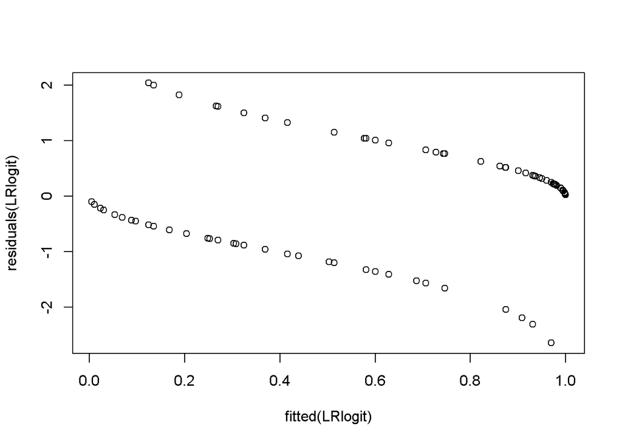

```r
plot(residuals(LRlogit) ~ fitted(LRlogit))
```

```r
coef(LRlogit)
```

```
## (Intercept)         TCP     RWMAMed        NCPY        ACPY       EFMed
##   1.8294680   3.4047423  -2.6388199  -1.4209405   0.4692772  -1.5196451
##      AgeMed         HTN          DM
##  -1.6129894   0.8657150   1.8719128
```

```r
LRPred <- data.frame(predict(LRlogit, type = "response"))
names(LRPred)[1]<-"Predict"

N <- sum(LRPred$Predict < 0.50)
C <- sum(LRPred$Predict >= 0.50)
(N/C)*100
```

```
## [1] 36.52695
```

### GLM Output interpretation:

#### HTN: For a one unit increase in HTN, the log odds of being diagnosed with Coronary Artery Disease increases by 0.8657

#### DM: For a one unit increase in DM, the log odds of being diagnosed with Coronary Artery Disease increases by 1.8719

### Documenting and plotting the stability of the algorithms using different numbers of ‘folds’ during cross validation - starting with the Random Forest algorithm:

```r
RFstability <- data.frame(Accuracy=rep(0.9467,7), Sensitivity=rep(0.9630, 7), Specificity=rep(0.9048,7))
rownames(RFstability) <- c(3,5,7,10,15,20,25)
RFstability
```

```
##    Accuracy Sensitivity Specificity
## 3    0.9467       0.963      0.9048
## 5    0.9467       0.963      0.9048
## 7    0.9467       0.963      0.9048
## 10   0.9467       0.963      0.9048
## 15   0.9467       0.963      0.9048
## 20   0.9467       0.963      0.9048
## 25   0.9467       0.963      0.9048
```

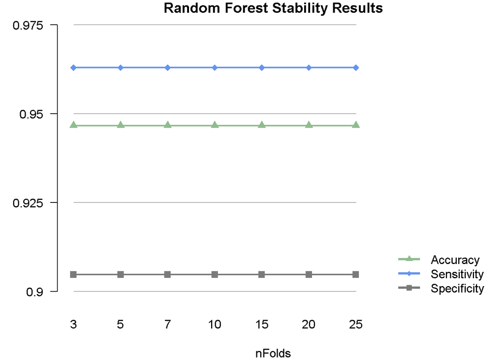

```r
cols <- c("darkseagreen","cornflowerblue","gray48")
pch <- c(17,18,15)
xmax <- nrow(RFstability) + 2.5
par(mar=c(4,4,1,1))
plot(1:nrow(RFstability), 1:nrow(RFstability), pch="",
        xlab="nFolds", ylab=NA, xaxt="n", yaxt="n",
        ylim=c(.9,.975), bty="n", xlim=c(1,xmax), main="Random Forest Stability Results")
for (i in seq(.9,.975,by=.025)) {
    lines(1:nrow(RFstability), rep(i,nrow(RFstability)), col="gray69")
}
for (i in 1:ncol(RFstability)) {

    points(1:nrow(RFstability), RFstability[,i], pch=pch[i],
        col=cols[i], cex=1.2)

    lines(1:nrow(RFstability), RFstability[,i], col=cols[i],
        lwd=2)
}
axis(side=1, at=1:nrow(RFstability), tick=FALSE,
        labels=rownames(RFstability))

axis(side=1, at=seq(-0.5,8.5,by=1),
        tick=FALSE, labels=NA)

axis(side=2, at=seq(.9,.975,by=.025), tick=TRUE,
        las=TRUE, labels=paste(seq(.9,.975,by=.025)))

legend('bottomright',legend=colnames(RFstability), pch=pch,
        col=cols, cex=1.0, bty="n",  lwd=3, lty=1)
```

#### Next, plotting the stability of the Naive Bayes algorithm:

```r
NBstability <- data.frame(Accuracy=c(0.9200, 0.9200, 0.9333, 0.9067, 0.9067, 0.9200, 0.9200), Sensitivity=c(0.8889, 0.8889, 0.9074, 0.8704, 0.8889, 0.8889, 0.8889), Specificity=c(1.0, 1.0, 1.0, 1.0, 0.9524, 1.0, 1.0))
rownames(NBstability) <- c(3,5,7,10,15,20,25)
NBstability
```

```
##    Accuracy Sensitivity Specificity
## 3    0.9200      0.8889      1.0000
## 5    0.9200      0.8889      1.0000
## 7    0.9333      0.9074      1.0000
## 10   0.9067      0.8704      1.0000
## 15   0.9067      0.8889      0.9524
## 20   0.9200      0.8889      1.0000
## 25   0.9200      0.8889      1.0000
```

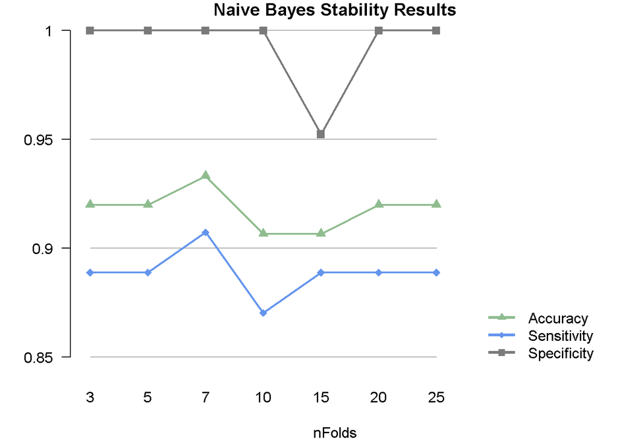

```r
cols <- c("darkseagreen","cornflowerblue","gray48")
pch <- c(17,18,15)
xmax <- nrow(NBstability) + 2.5
par(mar=c(4,4,1,1))
plot(1:nrow(NBstability), 1:nrow(NBstability), pch="",
        xlab="nFolds", ylab=NA, xaxt="n", yaxt="n",
        ylim=c(.85,1.0), bty="n", xlim=c(1,xmax), main="Naive Bayes Stability Results")
for (i in seq(.85,1.0,by=.05)) {
    lines(1:nrow(NBstability), rep(i,nrow(NBstability)), col="gray69")
}
for (i in 1:ncol(RFstability)) {

    points(1:nrow(NBstability), NBstability[,i], pch=pch[i],
        col=cols[i], cex=1.2)

    lines(1:nrow(NBstability), NBstability[,i], col=cols[i],
        lwd=2)
}
axis(side=1, at=1:nrow(NBstability), tick=FALSE,
        labels=rownames(NBstability))

axis(side=1, at=seq(-0.5,8.5,by=1),
        tick=FALSE, labels=NA)

axis(side=2, at=seq(.85,1.0,by=.05), tick=TRUE,
        las=TRUE, labels=paste(seq(.85,1.0,by=.05)))

legend('bottomright',legend=colnames(NBstability), pch=pch,
        col=cols, cex=1.0, bty="n",  lwd=3, lty=1)
```

#### Lastly, plotting the stability of the Logistic Regression algorithm:

```r
LRstability <- data.frame(Accuracy=rep(0.9333,7), Sensitivity=rep(0.9630,7), Specificity=rep(0.8571,7))
rownames(LRstability) <- c(3,5,7,10,15,20,25)
RFstability
```

```
##    Accuracy Sensitivity Specificity
## 3    0.9467       0.963      0.9048
## 5    0.9467       0.963      0.9048
## 7    0.9467       0.963      0.9048
## 10   0.9467       0.963      0.9048
## 15   0.9467       0.963      0.9048
## 20   0.9467       0.963      0.9048
## 25   0.9467       0.963      0.9048
```

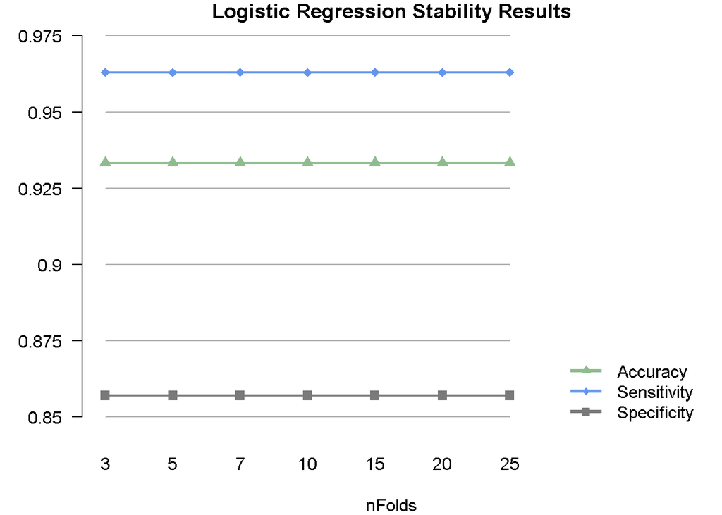

```r
cols <- c("darkseagreen","cornflowerblue","gray48")
pch <- c(17,18,15)
xmax <- nrow(LRstability) + 2.5
par(mar=c(4,4,1,1))
plot(1:nrow(LRstability), 1:nrow(LRstability), pch="",
        xlab="nFolds", ylab=NA, xaxt="n", yaxt="n",
        ylim=c(.85,.975), bty="n", xlim=c(1,xmax), main="Logistic Regression Stability Results")
for (i in seq(.85,.975,by=.025)) {
    lines(1:nrow(LRstability), rep(i,nrow(LRstability)), col="gray69")
}
for (i in 1:ncol(LRstability)) {

    points(1:nrow(LRstability), LRstability[,i], pch=pch[i],
        col=cols[i], cex=1.2)

    lines(1:nrow(LRstability), LRstability[,i], col=cols[i],
        lwd=2)
}
axis(side=1, at=1:nrow(LRstability), tick=FALSE,
        labels=rownames(RFstability))

axis(side=1, at=seq(-0.5,8.5,by=1),
        tick=FALSE, labels=NA)

axis(side=2, at=seq(.85,.975,by=.025), tick=TRUE,
        las=TRUE, labels=paste(seq(.85,.975,by=.025)))

legend('bottomright',legend=colnames(LRstability), pch=pch,
        col=cols, cex=1.0, bty="n",  lwd=3, lty=1)
```

#### Plotting the duration of each of the three algorithms for each of the seven different folds:

```r
Duration <- data.frame(Rforest=c(6.97, 6.95, 6.97, 6.85, 6.91, 6.89, 7.14), NBayes=c(5.11, 6.39, 7.39, 8.86, 12.14, 14.50, 18.30), LRegression=c(2.84, 3.77, 4.99, 5.50, 7.77, 9.61, 11.25))
rownames(Duration) <- c(3,5,7,10,15,20,25)
Duration
```

```
##    Rforest NBayes LRegression
## 3     6.97   5.11        2.84
## 5     6.95   6.39        3.77
## 7     6.97   7.39        4.99
## 10    6.85   8.86        5.50
## 15    6.91  12.14        7.77
## 20    6.89  14.50        9.61
## 25    7.14  18.30       11.25
```

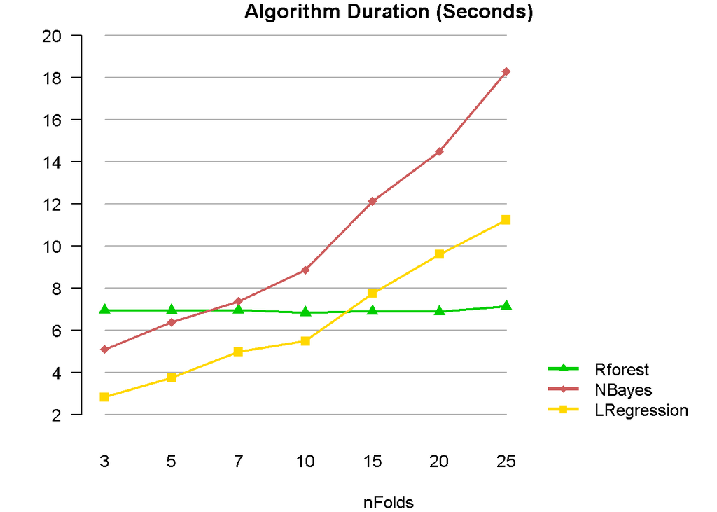

```r
cols <- c("green3","indianred","gold")
pch <- c(17,18,15)
xmax <- nrow(Duration) + 2.5
par(mar=c(4,4,1,1))
plot(1:nrow(Duration), 1:nrow(Duration), pch="",
        xlab="nFolds", ylab=NA, xaxt="n", yaxt="n",
        ylim=c(2,20), bty="n", xlim=c(1,xmax), main="Algorithm Duration (Seconds)")
for (i in seq(2, 20,by=2)) {
    lines(1:nrow(Duration), rep(i,nrow(Duration)), col="gray69")
}
for (i in 1:ncol(Duration)) {

    points(1:nrow(Duration), Duration[,i], pch=pch[i],
        col=cols[i], cex=1.2)

    lines(1:nrow(Duration), Duration[,i], col=cols[i],
        lwd=2)
}
axis(side=1, at=1:nrow(Duration), tick=FALSE,
        labels=rownames(Duration))

axis(side=1, at=seq(-0.5,8.5,by=1),
        tick=FALSE, labels=NA)

axis(side=2, at=seq(2,20,by=2), tick=TRUE,
        las=TRUE, labels=paste(seq(2,20,by=2)))

legend('bottomright',legend=colnames(Duration), pch=pch,
        col=cols, cex=1.0, bty="n",  lwd=3, lty=1)
```

#### Computing the Cliff’s Delta effect size (for ordinal variables):

```r
library(effsize)

RFacc <- rep(0.9467,7)
RFsens <- rep(0.9630, 7)
RFspec <- rep(0.9048,7)

NBacc <- c(0.9200, 0.9200, 0.9333, 0.9067, 0.9067, 0.9200, 0.9200)
NBsens <- c(0.8889, 0.8889, 0.9074, 0.8704, 0.8889, 0.8889, 0.8889)
NBspec <- c(1.0, 1.0, 1.0, 1.0, 0.9524, 1.0, 1.0)

LRacc <- rep(0.9333,7)
LRsens <- rep(0.9630,7)
LRspec <- rep(0.8571,7)

RFNBaccDelta <- cliff.delta(RFacc, NBacc)
RFNBaccDelta
```

```
##
## Cliff's Delta
##
## delta estimate: 1 (large)
## 95 percent confidence interval:
##     lower     upper
## 0.9311004 1.0000000
```

```r
RFLRaccDelta <- cliff.delta(RFacc, LRacc)
RFLRaccDelta
```

```
##
## Cliff's Delta
##
## delta estimate: 1 (large)
## 95 percent confidence interval:
##     lower     upper
## 0.9311004 1.0000000
```

```r
LRNBaccDelta <- cliff.delta(LRacc, NBacc)
LRNBaccDelta
```

```
##
## Cliff's Delta
##
## delta estimate: 0.8571429 (large)
## 95 percent confidence interval:
##     lower     upper
## 0.2763886 0.9793409
```

```r
RFNBsensDelta <- cliff.delta(RFsens, NBsens)
RFNBsensDelta
```

```
##
## Cliff's Delta
##
## delta estimate: 1 (large)
## 95 percent confidence interval:
##     lower     upper
## 0.9311004 1.0000000
```

```r
RFLRsensDelta <- cliff.delta(RFsens, LRsens)
RFLRsensDelta
```

```
##
## Cliff's Delta
##
## delta estimate: 0 (negligible)
## 95 percent confidence interval:
## lower upper
##     0     0
```

```r
LRNBsensDelta <- cliff.delta(LRsens, NBsens)
LRNBsensDelta
```

```
##
## Cliff's Delta
##
## delta estimate: 1 (large)
## 95 percent confidence interval:
##     lower     upper
## 0.9311004 1.0000000
```

```r
RFNBspecDelta <- cliff.delta(RFspec, NBspec)
RFNBspecDelta
```

```
##
## Cliff's Delta
##
## delta estimate: -1 (large)
## 95 percent confidence interval:
##      lower      upper
## -1.0000000 -0.9311004
```

```r
RFLRspecDelta <- cliff.delta(RFspec, LRspec)
RFLRspecDelta
```

```
##
## Cliff's Delta
##
## delta estimate: 1 (large)
## 95 percent confidence interval:
##     lower     upper
## 0.9311004 1.0000000
```

```r
LRNBspecDelta <- cliff.delta(LRspec, NBspec)
LRNBspecDelta
```

```
##
## Cliff's Delta
##
## delta estimate: -1 (large)
## 95 percent confidence interval:
##      lower      upper
## -1.0000000 -0.9311004
```